# Stat 420 Data Project

Hartman, Peter; Hong, Ron; Banerjee, Santu; Manning, Colton

8/6/2021

# Stat 420 Data Project

## Predicting Rainfall in Australia

### Introduction

Australia is an amazing continent. It has practically every biome imaginable, with the exception of tundra or permafrost. With vast deserts, winding mountain ranges, swamps and marshes, and some of the most amazing coastlines, the geography and associated weather of Australia produces a widely varied amount of rainfall.

This project will look at rainfall amounts in varied geographical regions in Australia. It will devise a model to try to fit the data, and predict the amount of rainfall given humidity and other factors.

### Data Curation

For this project, we decided to use the “Rain in Australia” dataset, homed on Kaggle at: https://www.kaggle.com/jsphyg/weather-dataset-rattle-package.

This dataset consists of 23 variables with 145,460 observations. While this is a thorough dataset, many of the variables are factors of others, and some are consistently missing values. Data curation is needed to remove and consolidate the data as needed.

First, we combined the airport observations with the associated city observations. The airports were close to the cities to count as additional observations.

Finally, we limited the locations to specific cities.

| Locations | Observations | Geography | Use |
| --- | --- | --- | --- |
| AliceSprings | 2223 | Subtropical Desert | Yes |
| Brisbane | 2953 | Coastal Flatland | Yes |
| Cairns | 2444 | Coastal Rainforest | Yes |
| Darwin | 3062 | Coastal Flatland | Yes |
| Melbourne | 4827 | Coastal Mountain | Yes |
| Mildura | 2594 | Flatland | Yes |
| MountGambier | 2465 | Mountain | Yes |
| NorfolkIsland | 2464 | Island Mountain | Yes |
| Perth | 5938 | Coastal Flatland | Yes |
| Sydney | 4560 | Coastal Mountain | Yes |
| WaggaWagga | 2416 | Flatland | Yes |
| Watsonia | 2730 | Coastal Mountain | Yes |
| Woomera | 1734 | Desert | Yes |
| Canberra | 1078 | Wetlands | No |
| Cobar | 534 | Semi-Arid | No |
| CoffsHarbour | 1380 | Coastal Mountain | No |
| Hobart | 1939 | Coastal Mountain | No |
| Moree | 1913 | Flatland | No |
| Nuriootpa | 2008 | Coastal Flatland | No |
| Portland | 1863 | Coastal Flatland | No |
| Sale | 1678 | Coastal Flatland | No |
| Townsville | 2419 | Coastal Flatland | No |
| Williamtown | 1198 | Coastal Flatland | No |

We then set the date to only use the month section, as we did not care about the year.

Finally, we created out test and training data sets, setting the test data set to 40% of the total observations, and the training data set to the remaining 60%.

Our settings and calculations can be found in Appendix B

## Description of Variables

### “Date”

The date of observation

### “Location”

The common name of the location of the weather station

### “MinTemp”

The minimum temperature in degrees celsius

### “MaxTemp”

The maximum temperature in degrees celsius

### “Rainfall”

The amount of rainfall recorded for the day in mm

### “Evaporation”

The so-called Class A pan evaporation (mm) in the 24 hours to 9am

### “Sunshine”

The number of hours of bright sunshine in the day.

### “WindGustDir”

The direction of the strongest wind gust in the 24 hours to midnight

### “WindGustSpeed”

The speed (km/h) of the strongest wind gust in the 24 hours to midnight

### “WindDir9am”

Direction of the wind at 9am

### “WindDir3pm”

Direction of the wind at 3pm

### “WindSpeed9am”

Wind speed (km/hr) averaged over 10 minutes prior to 9am

### “WindSpeed3pm”

Wind speed (km/hr) averaged over 10 minutes prior to 3pm

### “Humidity9am”

Humidity (percent) at 9am

### “Humidity3pm”

Humidity (percent) at 3pm

### “Pressure9am”

Atmospheric pressure (hpa) reduced to mean sea level at 9am

### “Pressure3pm”

Atmospheric pressure (hpa) reduced to mean sea level at 3pm

### “Cloud9am”

Fraction of sky obscured by cloud at 9am. This is measured in “oktas”, which are a unit of eigths. It records how many eigths of the sky are obscured by cloud. A 0 measure indicates completely clear sky whilst an 8 indicates that it is completely overcast.

### “Cloud3pm”

Fraction of sky obscured by cloud (in “oktas”: eighths) at 3pm. See Cload9am for a description of the values

### “Temp9am”

Temperature (degrees C) at 9am

### “Temp3pm”

Temperature (degrees C) at 3pm

### “RainToday”

Boolean: 1 if precipitation (mm) in the 24 hours to 9am exceeds 1mm, otherwise 0

### “RainTomorrow”

The amount of next day rain in mm. Used to create response variable RainTomorrow. A kind of measure of the “risk”.

### Model Selection

After looking at all of these additive models, we look at these methods of creating models, we try different methods.

First, we try an additive model. We began with an additive model that contained no predictors, and ran a forwards stepwise search, with AIC and BIC, to try to find a model that fit the data.

```r
mod_start = lm(Rainfall ~ 1, data = weather_trn)
forward_AIC = step(mod_start, scope = Rainfall ~ Date + Location + Evaporation + Sunshine + Humidity9am + Pressure9am + Cloud9am + Temp9am + RainToday, direction = "forward", trace = 0)
forward_BIC = step(mod_start, scope = Rainfall ~ Date + Location + Evaporation + Sunshine + Humidity9am + Pressure9am + Cloud9am + Temp9am + RainToday, direction = "forward", trace = 0, k = log(nrow(weather_trn)))
```

This produced two similar models, shown here with $anova tables:

```r
summary(forward_AIC)$call
```

```
## lm(formula = Rainfall ~ RainToday + Location + Sunshine + Pressure9am +
##     Humidity9am + Evaporation + Date + Temp9am, data = weather_trn)
```

```r
forward_AIC$anova
```

```
##            Step  Df    Deviance Resid. Df Resid. Dev       AIC
## 1                NA          NA     27036  1395358.9 106627.83
## 2   + RainToday  -1 426223.4606     27035   969135.5  96774.78
## 3    + Location -12  12353.9252     27023   956781.5  96451.91
## 4    + Sunshine  -1  10498.6750     27022   946282.9  96155.60
## 5 + Pressure9am  -1   7679.3734     27021   938603.5  95937.29
## 6 + Humidity9am  -1   4745.5902     27020   933857.9  95802.24
## 7 + Evaporation  -1   5271.3644     27019   928586.5  95651.20
## 8        + Date  -1    223.1593     27018   928363.4  95646.70
## 9     + Temp9am  -1    310.2231     27017   928053.2  95639.66
```

```r
summary(forward_BIC)$call
```

```
## lm(formula = Rainfall ~ RainToday + Pressure9am + Humidity9am +
##     Location + Sunshine + Evaporation, data = weather_trn)
```

```r
forward_BIC$anova
```

```
##            Step  Df   Deviance Resid. Df Resid. Dev       AIC
## 1                NA         NA     27036  1395358.9 106636.04
## 2   + RainToday  -1 426223.461     27035   969135.5  96791.19
## 3 + Pressure9am  -1  11566.582     27034   957568.9  96476.77
## 4 + Humidity9am  -1   8568.753     27033   949000.1  96243.94
## 5    + Location -12  11081.181     27021   937918.9  96048.84
## 6    + Sunshine  -1   4061.047     27020   933857.9  95941.73
## 7 + Evaporation  -1   5271.364     27019   928586.5  95798.88
```

Next, we did the same with a backwards search. We started with all of the predictors, and ran the stepwise search backwards to generate calls that might help narrow down the model.

```r
mod_start_bkw = lm(Rainfall ~ ., data = weather_trn)
backward_AIC = step(mod_start_bkw, direction = "backward", trace = 0)
backward_BIC = step(mod_start_bkw, direction = "backward", k = log(nrow(weather_trn)), trace = 0)
```

This produced two calls, again shown with $anova tables:

```r
summary(backward_AIC)$call
```

```
## lm(formula = Rainfall ~ Date + Location + MinTemp + MaxTemp +
##     Evaporation + Sunshine + WindGustSpeed + WindDir3pm + WindSpeed9am +
##     WindSpeed3pm + Humidity9am + Humidity3pm + Pressure9am +
##     Pressure3pm + Cloud9am + Cloud3pm + Temp9am + Temp3pm + RainToday,
##     data = weather_trn)
```

```r
backward_AIC$anova
```

```
##            Step Df  Deviance Resid. Df Resid. Dev      AIC
## 1               NA        NA     27004   917889.0 95367.91
## 2 - WindGustDir  1  4.555415     27005   917893.5 95366.05
## 3  - WindDir9am  1 12.530638     27006   917906.0 95364.42
```

```r
summary(backward_BIC)$call
```

```
## lm(formula = Rainfall ~ Location + MinTemp + MaxTemp + Evaporation +
##     Sunshine + WindGustSpeed + WindSpeed3pm + Humidity9am + Humidity3pm +
##     Pressure9am + Pressure3pm + Cloud3pm + Temp3pm + RainToday,
##     data = weather_trn)
```

```r
backward_BIC$anova
```

```
##             Step Df   Deviance Resid. Df Resid. Dev      AIC
## 1                NA         NA     27004   917889.0 95638.68
## 2  - WindGustDir  1   4.555415     27005   917893.5 95628.61
## 3   - WindDir9am  1  12.530638     27006   917906.0 95618.77
## 4   - WindDir3pm  1  95.808258     27007   918001.8 95611.39
## 5      - Temp9am  1 123.979984     27008   918125.8 95604.83
## 6     - Cloud9am  1 229.315550     27009   918355.1 95601.38
## 7         - Date  1 196.229691     27010   918551.4 95596.95
## 8 - WindSpeed9am  1 330.994362     27011   918882.4 95596.49
```

Finally, the group tried a both direction search:

```r
mod_start = lm(Rainfall ~ 1, data = weather_trn)
stepwise_AIC = step(mod_start, scope = Rainfall ~ Date + Location + Evaporation + Sunshine + Humidity9am + Pressure9am + Cloud9am + Temp9am + RainToday, direction = "both", trace = 0)
stepwise_BIC = step(mod_start, scope = Rainfall ~ Date + Location + Evaporation + Sunshine + Humidity9am + Pressure9am + Cloud9am + Temp9am + RainToday, direction = "both", trace = 0, k = log(nrow(weather_trn)))
```

Again, shown with $anova tables:

```r
summary(stepwise_AIC)$call
```

```
## lm(formula = Rainfall ~ RainToday + Location + Sunshine + Pressure9am +
##     Humidity9am + Evaporation + Date + Temp9am, data = weather_trn)
```

```r
stepwise_AIC$anova
```

```
##            Step  Df    Deviance Resid. Df Resid. Dev       AIC
## 1                NA          NA     27036  1395358.9 106627.83
## 2   + RainToday  -1 426223.4606     27035   969135.5  96774.78
## 3    + Location -12  12353.9252     27023   956781.5  96451.91
## 4    + Sunshine  -1  10498.6750     27022   946282.9  96155.60
## 5 + Pressure9am  -1   7679.3734     27021   938603.5  95937.29
## 6 + Humidity9am  -1   4745.5902     27020   933857.9  95802.24
## 7 + Evaporation  -1   5271.3644     27019   928586.5  95651.20
## 8        + Date  -1    223.1593     27018   928363.4  95646.70
## 9     + Temp9am  -1    310.2231     27017   928053.2  95639.66
```

```r
summary(stepwise_BIC)$call
```

```
## lm(formula = Rainfall ~ RainToday + Pressure9am + Humidity9am +
##     Location + Sunshine + Evaporation, data = weather_trn)
```

```r
stepwise_BIC$anova
```

```
##            Step  Df   Deviance Resid. Df Resid. Dev       AIC
## 1                NA         NA     27036  1395358.9 106636.04
## 2   + RainToday  -1 426223.461     27035   969135.5  96791.19
## 3 + Pressure9am  -1  11566.582     27034   957568.9  96476.77
## 4 + Humidity9am  -1   8568.753     27033   949000.1  96243.94
## 5    + Location -12  11081.181     27021   937918.9  96048.84
## 6    + Sunshine  -1   4061.047     27020   933857.9  95941.73
## 7 + Evaporation  -1   5271.364     27019   928586.5  95798.88
```

After looking at the additive-only models, no interaction, calculating LOOCV and RMSE, and looking at the adjusted $R^2$, we get:

|  | RSME_loocv | RMSE_test | adjusted_r_squared | model_call |
| --- | --- | --- | --- | --- |
| forward_AIC | 5.864218 | 6.063387 | 0.1004153 | lm, Rainfall ~ RainToday + Location + Sunshine + Pressure9am + Humidity9am + Evaporation + Date + Temp9am, weather_trn |
| forward_BIC | 5.865340 | 6.063625 | 0.1004926 | lm, Rainfall ~ RainToday + Pressure9am + Humidity9am + Location + Sunshine + Evaporation, weather_trn |
| backward_AIC | 5.834493 | 6.029268 | 0.1047418 | lm, Rainfall ~ Date + Location + MinTemp + MaxTemp + Evaporation + Sunshine + WindGustSpeed + WindDir3pm + WindSpeed9am + WindSpeed3pm + Humidity9am + Humidity3pm + Pressure9am + Pressure3pm + Cloud9a… |
| backward_BIC | 5.836562 | 6.032952 | 0.1044817 | lm, Rainfall ~ Location + MinTemp + MaxTemp + Evaporation + Sunshine + WindGustSpeed + WindSpeed3pm + Humidity9am + Humidity3pm + Pressure9am + Pressure3pm + Cloud3pm + Temp3pm + RainToday, weather_tr… |
| stepwise_AIC | 5.864218 | 6.063387 | 0.1004153 | lm, Rainfall ~ RainToday + Location + Sunshine + Pressure9am + Humidity9am + Evaporation + Date + Temp9am, weather_trn |
| stepwise_BIC | 5.865340 | 6.063625 | 0.1004926 | lm, Rainfall ~ RainToday + Pressure9am + Humidity9am + Location + Sunshine + Evaporation, weather_trn |

With an adjusted $R^2$ around .10, it is obvious that an additive-only model would not work. We will need to try some interactions.

```r
mod_start = lm(Rainfall ~ 1, data = weather_trn)
forward_AIC_int = step(mod_start, scope = Rainfall ~ (Evaporation + Sunshine + Humidity9am + Pressure9am + Cloud9am + Temp9am + RainToday + Date) * Location, direction = "forward", trace = 0)
forward_BIC_int = step(mod_start, scope = Rainfall ~ (Evaporation + Sunshine + Humidity9am + Pressure9am + Cloud9am + Temp9am + RainToday + Date) * Location, direction = "forward", trace = 0, k = log(nrow(weather_trn)))
```

After starting with no predictors, we move forwards stepwise with interactions on Location.

```
## lm(formula = Rainfall ~ RainToday + Location + Sunshine + Pressure9am +
##     Humidity9am + Evaporation + Temp9am + Cloud9am + Date + RainToday:Location +
##     Location:Sunshine + Location:Pressure9am + Location:Evaporation +
##     Location:Temp9am + Location:Humidity9am + Location:Cloud9am +
##     Location:Date, data = weather_trn)
```

```
##                      Step  Df    Deviance Resid. Df Resid. Dev       AIC
## 1                          NA          NA     27036  1395358.9 106627.83
## 2             + RainToday  -1 426223.4606     27035   969135.5  96774.78
## 3              + Location -12  12353.9252     27023   956781.5  96451.91
## 4    + RainToday:Location -12  37652.9445     27011   919128.6  95390.40
## 5              + Sunshine  -1   8308.3249     27010   910820.3  95146.89
## 6     + Sunshine:Location -12  13029.9418     26998   897790.3  94781.32
## 7           + Pressure9am  -1   7613.8137     26997   890176.5  94553.05
## 8           + Humidity9am  -1   4866.3285     26996   885310.2  94406.84
## 9  + Pressure9am:Location -12   4142.1303     26984   881168.1  94304.05
## 10          + Evaporation  -1   3238.6155     26983   877929.4  94206.49
## 11 + Evaporation:Location -12   8071.9720     26971   869857.5  93980.75
## 12              + Temp9am  -1   2054.1319     26970   867803.3  93918.83
## 13     + Temp9am:Location -12  12847.1731     26958   854956.2  93539.58
## 14 + Humidity9am:Location -12   5204.9346     26946   849751.2  93398.47
## 15             + Cloud9am  -1    201.5472     26945   849549.7  93394.06
## 16    + Cloud9am:Location -12    870.8899     26933   848678.8  93390.33
## 17                 + Date  -1     71.9595     26932   848606.8  93390.04
## 18        + Date:Location -12   1139.5229     26920   847467.3  93377.71
```

```
## lm(formula = Rainfall ~ RainToday + Pressure9am + Humidity9am +
##     Location + Sunshine + Evaporation + Temp9am + RainToday:Location +
##     Location:Sunshine + Location:Evaporation + Pressure9am:Location +
##     Location:Temp9am + Humidity9am:Location, data = weather_trn)
```

```
##                      Step  Df   Deviance Resid. Df Resid. Dev       AIC
## 1                          NA         NA     27036  1395358.9 106636.04
## 2             + RainToday  -1 426223.461     27035   969135.5  96791.19
## 3           + Pressure9am  -1  11566.582     27034   957568.9  96476.77
## 4           + Humidity9am  -1   8568.753     27033   949000.1  96243.94
## 5              + Location -12  11081.181     27021   937918.9  96048.84
## 6    + RainToday:Location -12  37765.150     27009   900153.8  95060.14
## 7              + Sunshine  -1   2814.963     27008   897338.8  94985.66
## 8     + Sunshine:Location -12  12028.649     26996   885310.2  94743.24
## 9           + Evaporation  -1   2727.910     26995   882582.3  94670.01
## 10 + Evaporation:Location -12   7760.625     26983   874821.7  94553.68
## 11 + Pressure9am:Location -12   4964.183     26971   869857.5  94522.28
## 12              + Temp9am  -1   2054.132     26970   867803.3  94468.56
## 13     + Temp9am:Location -12  12847.173     26958   854956.2  94187.77
## 14 + Humidity9am:Location -12   5204.935     26946   849751.2  94145.13
```

```r
mod_start = lm(Rainfall ~ (Date + Evaporation + Sunshine + Humidity9am + Pressure9am + Cloud9am + Temp9am + RainToday) * Location, data = weather_trn)
backward_AIC_int = step(mod_start, direction = "backward", trace = 0)
backward_BIC_int = step(mod_start, direction = "backward", k = log(nrow(weather_trn)), trace = 0)
```

```r
summary(backward_AIC_int)$call
```

```
## lm(formula = Rainfall ~ (Date + Evaporation + Sunshine + Humidity9am +
##     Pressure9am + Cloud9am + Temp9am + RainToday) * Location,
##     data = weather_trn)
```

```r
backward_AIC_int$anova
```

```
##   Step Df Deviance Resid. Df Resid. Dev      AIC
## 1      NA       NA     26920   847467.3 93377.71
```

```r
summary(backward_BIC_int)$call
```

```
## lm(formula = Rainfall ~ Evaporation + Sunshine + Humidity9am +
##     Pressure9am + Temp9am + RainToday + Location + Evaporation:Location +
##     Humidity9am:Location + Pressure9am:Location + Temp9am:Location +
##     RainToday:Location, data = weather_trn)
```

```r
backward_BIC_int$anova
```

```
##                  Step Df  Deviance Resid. Df Resid. Dev      AIC
## 1                     NA        NA     26920   847467.3 94337.69
## 2 - Cloud9am:Location 12  849.1050     26932   848316.4 94242.30
## 3     - Date:Location 12 1151.1240     26944   849467.5 94156.51
## 4 - Sunshine:Location 12 2507.3738     26956   851974.9 94113.74
## 5              - Date  1  107.0565     26957   852082.0 94106.93
## 6          - Cloud9am  1  229.7246     26958   852311.7 94104.01
```

And stepwise search:

```r
mod_start = lm(Rainfall ~ 1, data = weather_trn)
stepwise_AIC_int = step(mod_start, scope = Rainfall ~ (Date + Evaporation + Sunshine + Humidity9am + Pressure9am + Cloud9am + Temp9am + RainToday) * Location, direction = "both", trace = 0)
stepwise_BIC_int = step(mod_start, scope = Rainfall ~ (Date + Evaporation + Sunshine + Humidity9am + Pressure9am + Cloud9am + Temp9am + RainToday) * Location, direction = "both", trace = 0, k = log(nrow(weather_trn)))
```

```
## lm(formula = Rainfall ~ RainToday + Location + Sunshine + Pressure9am +
##     Humidity9am + Evaporation + Temp9am + Cloud9am + Date + RainToday:Location +
##     Location:Sunshine + Location:Pressure9am + Location:Evaporation +
##     Location:Temp9am + Location:Humidity9am + Location:Cloud9am +
##     Location:Date, data = weather_trn)
```

```
##                      Step  Df    Deviance Resid. Df Resid. Dev       AIC
## 1                          NA          NA     27036  1395358.9 106627.83
## 2             + RainToday  -1 426223.4606     27035   969135.5  96774.78
## 3              + Location -12  12353.9252     27023   956781.5  96451.91
## 4    + RainToday:Location -12  37652.9445     27011   919128.6  95390.40
## 5              + Sunshine  -1   8308.3249     27010   910820.3  95146.89
## 6     + Sunshine:Location -12  13029.9418     26998   897790.3  94781.32
## 7           + Pressure9am  -1   7613.8137     26997   890176.5  94553.05
## 8           + Humidity9am  -1   4866.3285     26996   885310.2  94406.84
## 9  + Pressure9am:Location -12   4142.1303     26984   881168.1  94304.05
## 10          + Evaporation  -1   3238.6155     26983   877929.4  94206.49
## 11 + Evaporation:Location -12   8071.9720     26971   869857.5  93980.75
## 12              + Temp9am  -1   2054.1319     26970   867803.3  93918.83
## 13     + Temp9am:Location -12  12847.1731     26958   854956.2  93539.58
## 14 + Humidity9am:Location -12   5204.9346     26946   849751.2  93398.47
## 15             + Cloud9am  -1    201.5472     26945   849549.7  93394.06
## 16    + Cloud9am:Location -12    870.8899     26933   848678.8  93390.33
## 17                 + Date  -1     71.9595     26932   848606.8  93390.04
## 18        + Date:Location -12   1139.5229     26920   847467.3  93377.71
```

```
## lm(formula = Rainfall ~ RainToday + Pressure9am + Humidity9am +
##     Location + Sunshine + Evaporation + Temp9am + RainToday:Location +
##     Location:Evaporation + Pressure9am:Location + Location:Temp9am +
##     Humidity9am:Location, data = weather_trn)
```

```
##                      Step  Df   Deviance Resid. Df Resid. Dev       AIC
## 1                          NA         NA     27036  1395358.9 106636.04
## 2             + RainToday  -1 426223.461     27035   969135.5  96791.19
## 3           + Pressure9am  -1  11566.582     27034   957568.9  96476.77
## 4           + Humidity9am  -1   8568.753     27033   949000.1  96243.94
## 5              + Location -12  11081.181     27021   937918.9  96048.84
## 6    + RainToday:Location -12  37765.150     27009   900153.8  95060.14
## 7              + Sunshine  -1   2814.963     27008   897338.8  94985.66
## 8     + Sunshine:Location -12  12028.649     26996   885310.2  94743.24
## 9           + Evaporation  -1   2727.910     26995   882582.3  94670.01
## 10 + Evaporation:Location -12   7760.625     26983   874821.7  94553.68
## 11 + Pressure9am:Location -12   4964.183     26971   869857.5  94522.28
## 12              + Temp9am  -1   2054.132     26970   867803.3  94468.56
## 13     + Temp9am:Location -12  12847.173     26958   854956.2  94187.77
## 14 + Humidity9am:Location -12   5204.935     26946   849751.2  94145.13
## 15    - Location:Sunshine  12   2560.464     26958   852311.7  94104.01
```

Looking at the interaction models, we get:

|  | RSME_loocv | RMSE_test | adjusted_r_squared | model_call |
| --- | --- | --- | --- | --- |
| forward_AIC_int | 5.639080 | 5.818235 | 0.1325592 | lm, Rainfall ~ RainToday + Location + Sunshine + Pressure9am + Humidity9am + Evaporation + Temp9am + Cloud9am + Date + RainToday:Location + Location:Sunshine + Location:Pressure9am + Location:Evaporat… |
| forward_BIC_int | 5.641171 | 5.816451 | 0.1342508 | lm, Rainfall ~ RainToday + Pressure9am + Humidity9am + Location + Sunshine + Evaporation + Temp9am + RainToday:Location + Location:Sunshine + Location:Evaporation + Pressure9am:Location + Location:Tem… |
| backward_AIC_int | 5.639080 | 5.818235 | 0.1325592 | lm, Rainfall ~ (Date + Evaporation + Sunshine + Humidity9am + Pressure9am + Cloud9am + Temp9am + RainToday) * Location, weather_trn |
| backward_BIC_int | 5.646729 | 5.824950 | 0.1335255 | lm, Rainfall ~ Evaporation + Sunshine + Humidity9am + Pressure9am + Temp9am + RainToday + Location + Evaporation:Location + Humidity9am:Location + Pressure9am:Location + Temp9am:Location + RainToday:L… |
| stepwise_AIC_int | 5.639080 | 5.818235 | 0.1325592 | lm, Rainfall ~ RainToday + Location + Sunshine + Pressure9am + Humidity9am + Evaporation + Temp9am + Cloud9am + Date + RainToday:Location + Location:Sunshine + Location:Pressure9am + Location:Evaporat… |
| stepwise_BIC_int | 5.646729 | 5.824950 | 0.1335255 | lm, Rainfall ~ RainToday + Pressure9am + Humidity9am + Location + Sunshine + Evaporation + Temp9am + RainToday:Location + Location:Evaporation + Pressure9am:Location + Location:Temp9am + Humidity9am:L… |

> The best AIC model is `backward_AIC_int`

```
## lm(formula = Rainfall ~ (Date + Evaporation + Sunshine + Humidity9am +
##     Pressure9am + Cloud9am + Temp9am + RainToday) * Location,
##     data = weather_trn)
```

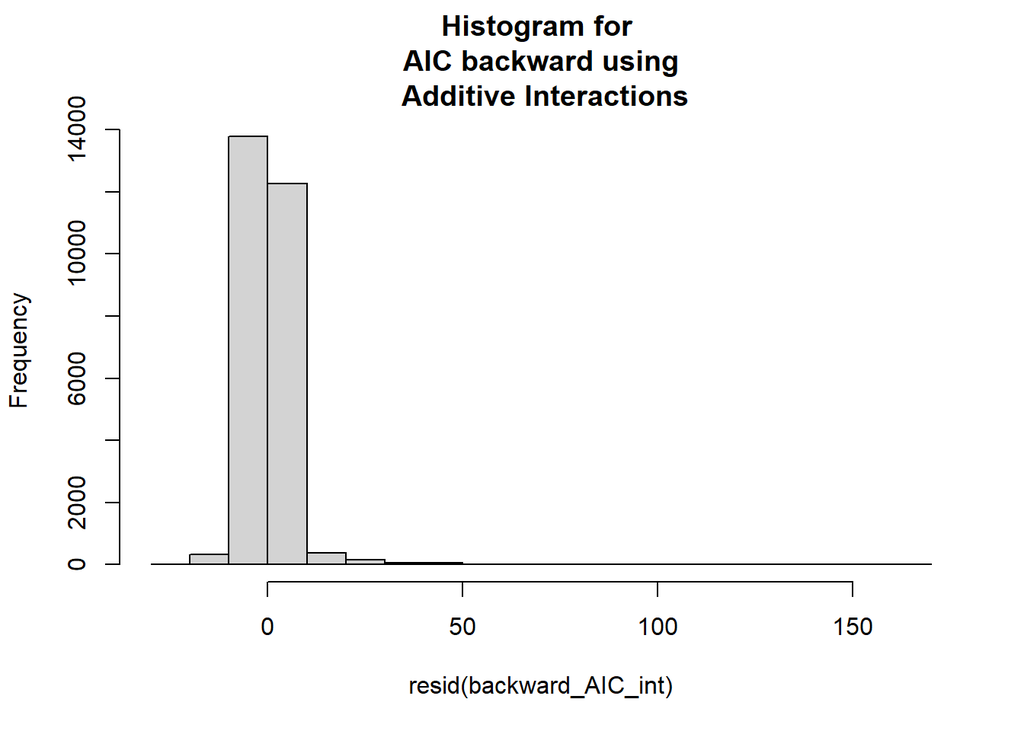

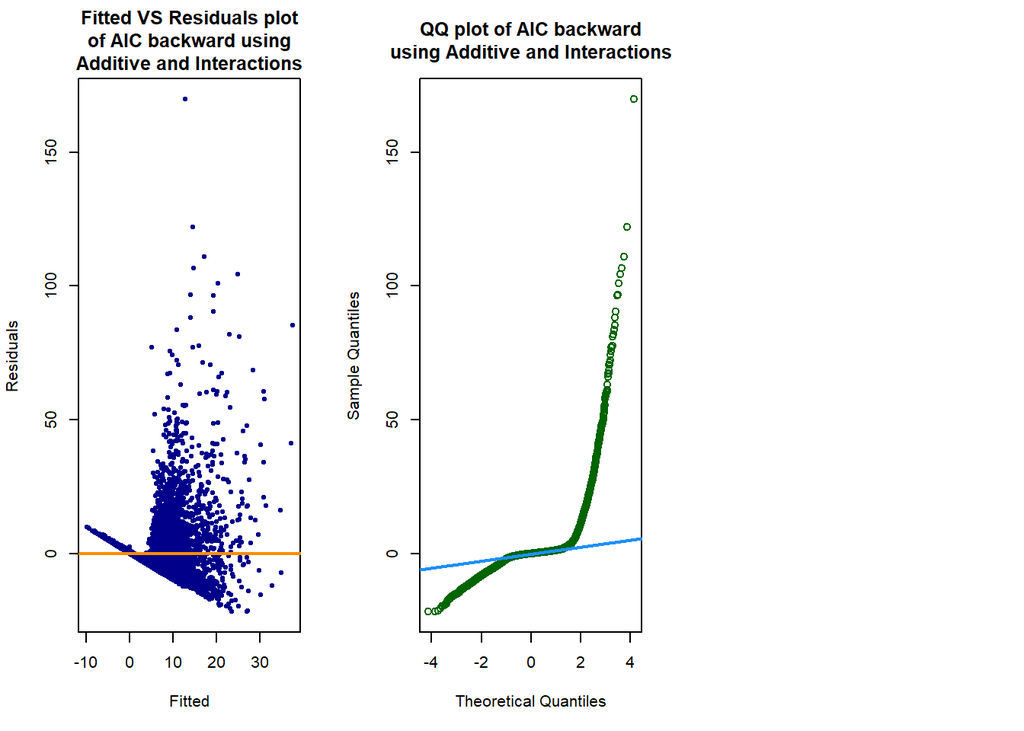

```
## lm(formula = Rainfall ~ Evaporation + Sunshine + Humidity9am +
##     Pressure9am + Temp9am + RainToday + Location + Evaporation:Location +
##     Humidity9am:Location + Pressure9am:Location + Temp9am:Location +
##     RainToday:Location, data = weather_trn)
```

[figure not shown]

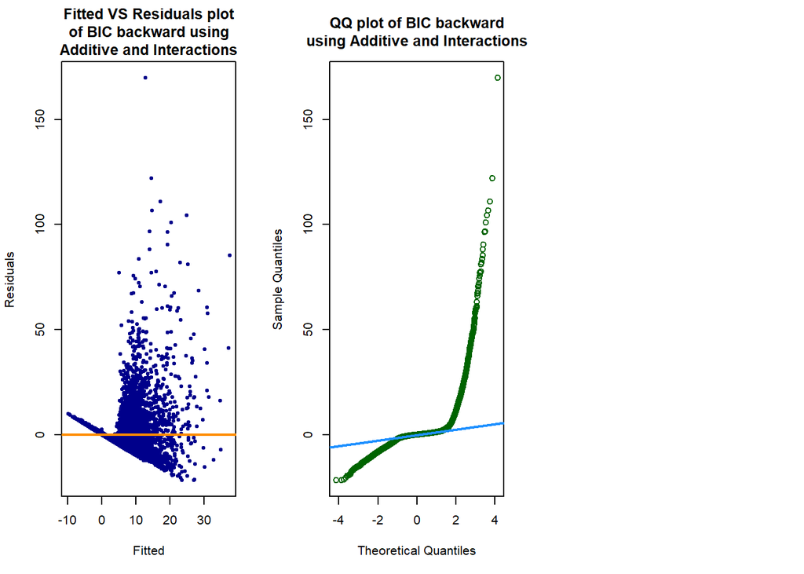

There were some possible outliers. We calculated cook’s distance on these, removed the outliers, and refit the models:

|  | RSME_loocv | RMSE_test | adjusted_r_squared | model_call |
| --- | --- | --- | --- | --- |
| AIC_refit | 5.639080 | 5.818235 | 0.1325592 | lm, Rainfall ~ (Date + Evaporation + Sunshine + Humidity9am + Pressure9am + Cloud9am + Temp9am + RainToday) * Location, weather_rmv_obs_AIC |
| BIC_refit | 5.646729 | 5.824950 | 0.1335255 | lm, Rainfall ~ Evaporation + Sunshine + Humidity9am + Pressure9am + Temp9am + RainToday + Location + Evaporation:Location + Humidity9am:Location + Pressure9am:Location + Temp9am:Location + RainToday:L… |

We also looked at other methods for finding models. We looked at the higher order method for finding models. Noticing that cloud cover played a roll in rainfall, we took higher order terms for cloud cover, then ran backward, forward, and stepwise models with AIC and BIC, to try to find the best fit.

After creating several models, we plotted them fitted vs residuals, as well as qq plots and histograms:

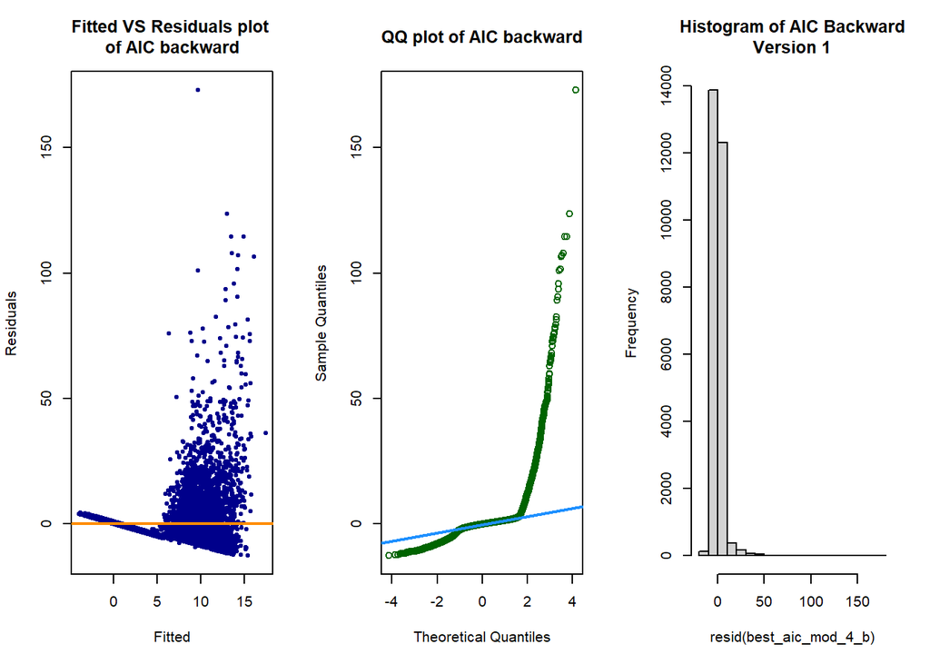

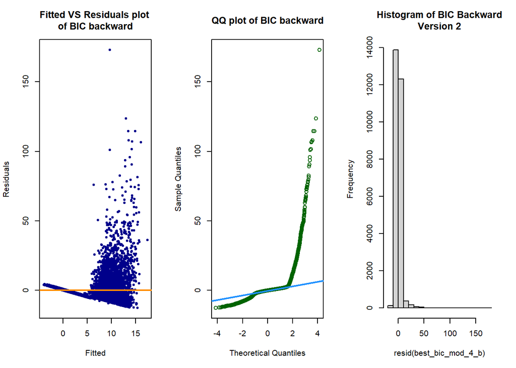

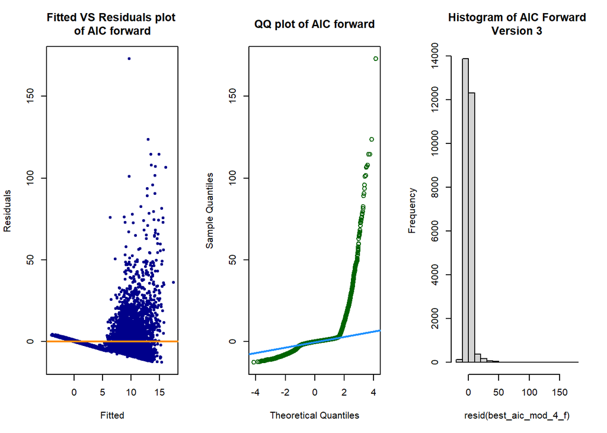

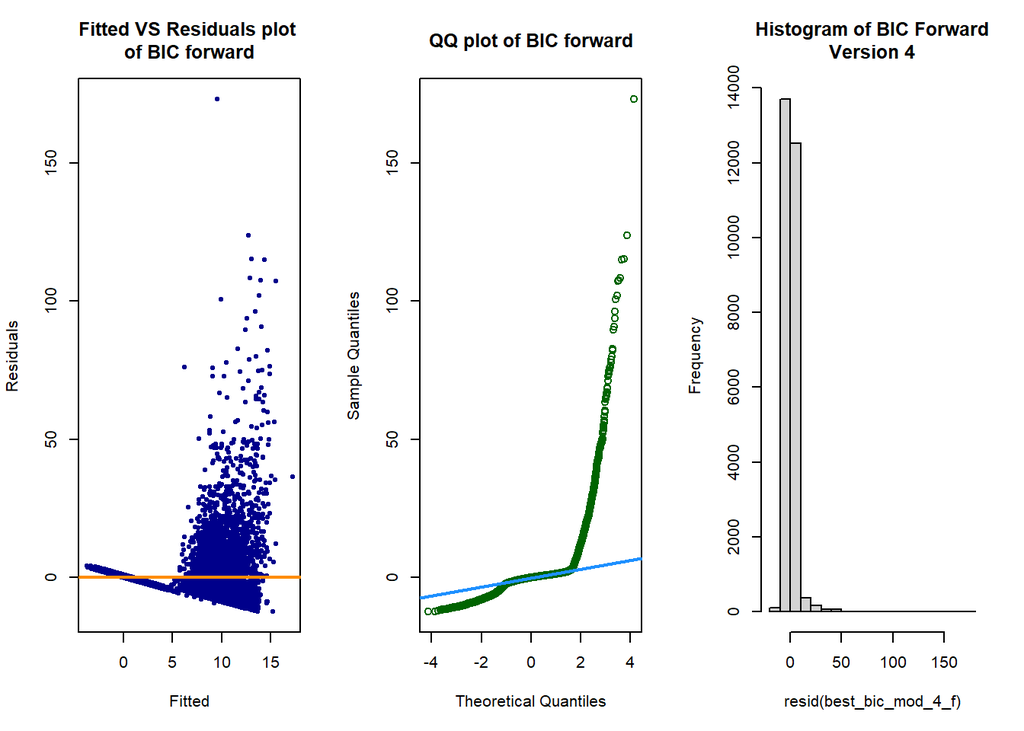

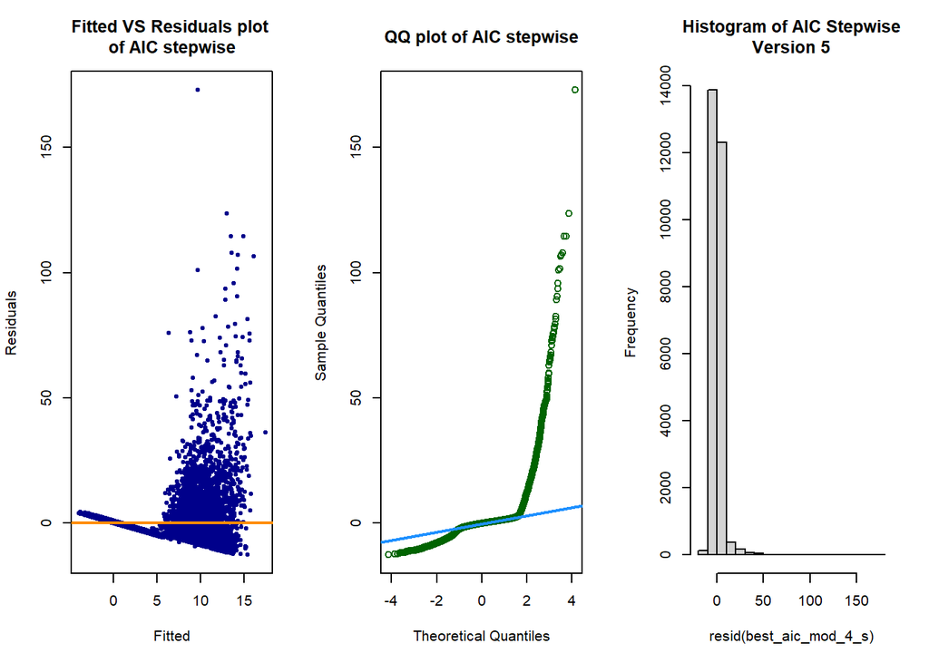

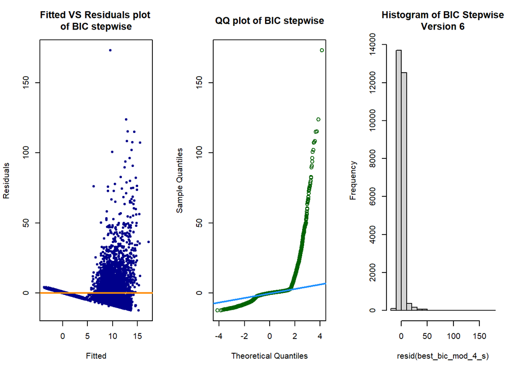

Stats for Best Models

| Model_names | RMSE_vals | Adj_r_sqr_vals | Loocv_rmse_vals |
| --- | --- | --- | --- |
| Best Backward AIC | 5.820589 | 0.3429352 | 5.827355 |
| Best Backward BIC | 5.820589 | 0.3429352 | 5.827355 |
| Best Forward AIC | 5.820589 | 0.3429352 | 5.827355 |
| Best Forward BIC | 5.834181 | 0.3400095 | 5.839778 |
| Best Stepwise AIC | 5.820589 | 0.3429352 | 5.827355 |
| Best Stepwise BIC | 5.834181 | 0.3400095 | 5.839778 |

Based on the above table values it seems Best Forward AIC is the best model since it has lowest LOOCV RMSE, RSS and highest adjusted R square.

We can see that the coefficients and number of predictors looks favorable.

```
##           (Intercept)          RainTodayYes         I(Cloud9am^4)
##           81.11382008            8.49098924            0.01063886
##      LocationBrisbane        LocationCairns        LocationDarwin
##            0.60793303            0.82667696            0.89850808
##     LocationMelbourne       LocationMildura  LocationMountGambier
##           -1.43606083           -1.03632044           -1.85123909
## LocationNorfolkIsland         LocationPerth        LocationSydney
##           -0.65440570           -0.44337448           -0.21995484
##    LocationWaggaWagga      LocationWatsonia       LocationWoomera
##           -0.84674128           -1.74888073           -1.03739574
##           Pressure9am         I(Cloud9am^3)           Humidity9am
##           -0.18673331           -0.14569723            0.01945117
##           Evaporation              Sunshine               Temp9am
##            0.14768580           -0.10536206           -0.21385925
##               Temp3pm           Humidity3pm           Pressure3pm
##            0.20155678            0.03038405            0.10510505
##         I(Cloud9am^2)              Cloud9am
##            0.64358376           -1.09013379
```

```
## [1] 26
```

| Model_info | RMSE_vals_step4 | Adj_r_sqr_vals_step4 |
| --- | --- | --- |
| Train | 5.820589 | 0.3429352 |
| Test | 6.019000 | 0.1065227 |

We find 762 influential points with this model.

Next we we step this model forward, removing the influential points. We can see the coefficients of the model below look a little better:

```
##           (Intercept)          RainTodayYes           Pressure9am
##          34.135252439           5.750099615          -0.106954554
##           Humidity9am      LocationBrisbane        LocationCairns
##           0.009149515          -0.095249455          -0.174777728
##        LocationDarwin     LocationMelbourne       LocationMildura
##           0.089806727          -0.709523817          -0.516236495
##  LocationMountGambier LocationNorfolkIsland         LocationPerth
##          -0.840349498          -0.533351183          -0.193021003
##        LocationSydney    LocationWaggaWagga      LocationWatsonia
##          -0.261457170          -0.416131108          -0.791005669
##       LocationWoomera         I(Cloud9am^4)         I(Cloud9am^3)
##          -0.403115568           0.003300713          -0.045450701
##           Pressure3pm           Evaporation              Sunshine
##           0.072937311           0.017717469          -0.024980744
##                  Date              Cloud3pm         I(Cloud9am^2)
##           0.014539869          -0.013238102           0.201860588
##              Cloud9am               Temp3pm               Temp9am
##          -0.326154732           0.057954487          -0.057961672
##           Humidity3pm
##           0.009456444
```

```
## [1] 28
```

And we can look at the variations between the Train and Test data applied to this model.

| Model_info_alt | RMSE_vals_step4_alt | Adj_r_sqr_vals_step4_alt |
| --- | --- | --- |
| Train | 2.20794 | 0.5599902 |
| Test | 6.30183 | 0.0680853 |

Finally, we take what we’ve learned to create our final model.

When adding log transformation in Rainfall then calculated Train RMSE and TEST Adjusted R^2 is value is very low.

Adding interaction and Polynomial transformation and only including significant predictors, we have selected below model.

```
##
## Call:
## lm(formula = Rainfall ~ (Humidity9am + Humidity3pm + Pressure3pm +
##     Evaporation) * RainToday + Pressure9am + I(Cloud9am^2) +
##     I(Cloud9am^3) + I(Cloud9am^4), data = weather_trn)
##
## Residuals:
##     Min      1Q  Median      3Q     Max
## -28.250  -0.203  -0.013   0.173 175.674
##
## Coefficients:
##                            Estimate Std. Error t value Pr(>|t|)
## (Intercept)               5.255e+00  6.977e+00   0.753 0.451317
## Humidity9am              -6.674e-04  3.265e-03  -0.204 0.838050
## Humidity3pm              -4.121e-03  2.949e-03  -1.398 0.162248
## Pressure3pm               8.176e-02  2.091e-02   3.910 9.26e-05 ***
## Evaporation              -1.861e-02  1.452e-02  -1.282 0.199991
## RainTodayYes              2.833e+02  1.275e+01  22.228  < 2e-16 ***
## Pressure9am              -8.643e-02  2.114e-02  -4.089 4.35e-05 ***
## I(Cloud9am^2)             1.429e-01  3.752e-02   3.808 0.000141 ***
## I(Cloud9am^3)            -5.384e-02  1.077e-02  -5.000 5.77e-07 ***
## I(Cloud9am^4)             4.829e-03  8.004e-04   6.034 1.62e-09 ***
## Humidity9am:RainTodayYes  1.423e-01  7.494e-03  18.983  < 2e-16 ***
## Humidity3pm:RainTodayYes  7.835e-02  6.056e-03  12.938  < 2e-16 ***
## Pressure3pm:RainTodayYes -2.895e-01  1.250e-02 -23.156  < 2e-16 ***
## Evaporation:RainTodayYes  7.798e-01  3.207e-02  24.315  < 2e-16 ***
## ---
## Signif. codes:  0 '***' 0.001 '**' 0.01 '*' 0.05 '.' 0.1 ' ' 1
##
## Residual standard error: 5.64 on 27023 degrees of freedom
## Multiple R-squared:  0.3841, Adjusted R-squared:  0.3838
## F-statistic:  1296 on 13 and 27023 DF,  p-value: < 2.2e-16
```

```
## [1] 0.3840657
```

with an adjusted $R^2$ of 0.3837694, and the following coefficients:

```r
coef(weather_step_5_aic)
```

```
##              (Intercept)              Humidity9am              Humidity3pm
##             5.255378e+00            -6.673653e-04            -4.121233e-03
##              Pressure3pm              Evaporation             RainTodayYes
##             8.176434e-02            -1.860506e-02             2.833319e+02
##              Pressure9am            I(Cloud9am^2)            I(Cloud9am^3)
##            -8.643341e-02             1.428845e-01            -5.383675e-02
##            I(Cloud9am^4) Humidity9am:RainTodayYes Humidity3pm:RainTodayYes
##             4.828989e-03             1.422570e-01             7.834715e-02
## Pressure3pm:RainTodayYes Evaporation:RainTodayYes
##            -2.894618e-01             7.797830e-01
```

using 14 predictors. Below we can see the plots and histogram for this model.

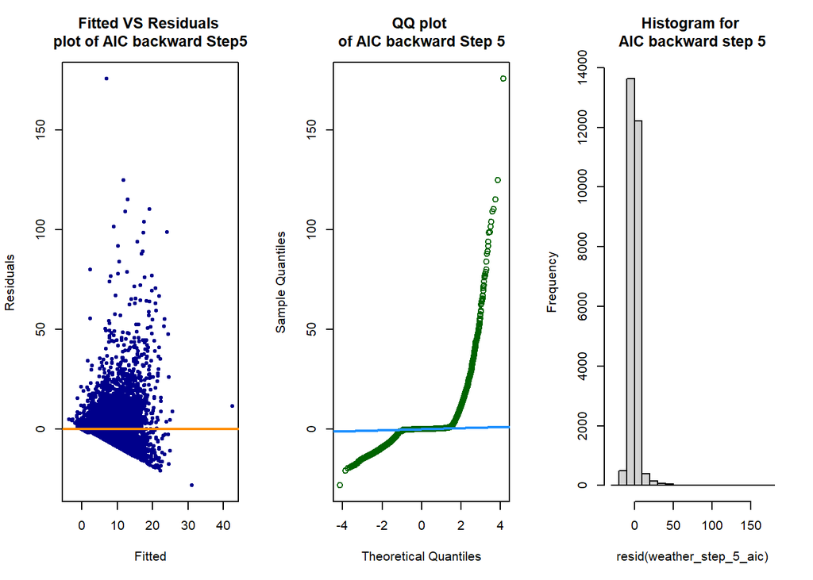

| Model_info_5 | RMSE_vals_step5_5 | Adj_r_sqr_vals_step5_5 |
| --- | --- | --- |
| Train | 5.638076 | 0.3837694 |
| Test | 5.857430 | 0.1318385 |

We are selecting this model since it is using only **14** predictors for the fitted model.

And as per above table, Test RMSE value is very close to Train RMSE value. Though TEST Adjusted R Square value is lower than Train Adjusted R square value, we found this model is a good fitted model since it is using less number of predictors and its probability of prediction is very good compare to other models that we selected before.

It is also possible that wind direction may play a role in the development of rainfall. After many experiments (please see Appendix D), the group tried a sinosoidal variation of wind direction, combined with interactions from above.

```r
rain_model4 = lm(
  log(Rainfall) ~ (
    Location + log(Evaporation + 0.1) + Sunshine +
      log(WindSpeed9am) + log(WindSpeed3pm) + Humidity9am + Humidity3pm +
      Pressure9am + Temp9am
  ) ^ 2 + (
    sin(Date * pi / 6) + cos(Date * pi / 6) +
      sin(WindDir9am * pi / 8) + cos(WindDir9am * pi / 8) +
      sin(WindDir3pm * pi / 8) + cos(WindDir3pm * pi / 8) +
      Cloud9am + I(Cloud9am ^ 2) + I(Cloud9am ^ 3) +
      Cloud3pm + I(Cloud3pm ^ 2) + I(Cloud3pm ^ 3)
  ) * (
    Location + log(Evaporation + 0.1) + Sunshine +
      log(WindSpeed9am) + log(WindSpeed3pm) + Humidity9am + Humidity3pm +
      Pressure9am + Temp9am
  ) + (sin(Date * pi / 6) + cos(Date * pi / 6)) * (
    sin(WindDir9am * pi / 8) + cos(WindDir9am * pi / 8) +
      sin(WindDir3pm * pi / 8) + cos(WindDir3pm * pi / 8) +
      Cloud9am + I(Cloud9am ^ 2) + I(Cloud9am ^ 3) +
      Cloud3pm + I(Cloud3pm ^ 2) + I(Cloud3pm ^ 3)
  ) + (sin(WindDir9am * pi / 8) + cos(WindDir9am * pi / 8)) * (
    sin(WindDir3pm * pi / 8) + cos(WindDir3pm * pi / 8) +
      Cloud9am + I(Cloud9am ^ 2) + I(Cloud9am ^ 3) +
      Cloud3pm + I(Cloud3pm ^ 2) + I(Cloud3pm ^ 3)
  ) + (sin(WindDir3pm * pi / 8) + cos(WindDir3pm * pi / 8)) * (
    Cloud9am + I(Cloud9am ^ 2) + I(Cloud9am ^ 3) +
      Cloud3pm + I(Cloud3pm ^ 2) + I(Cloud3pm ^ 3) +
      (Cloud9am + I(Cloud9am ^ 2) + I(Cloud9am ^ 3)) *
      (Cloud3pm + I(Cloud3pm ^ 2) + I(Cloud3pm ^ 3))
  ),
  data = subset(weather_trn, Rainfall > 0)
)
```

The $R^2$ for this model is 0.3507837. Calculating the LOOCV RMSE, we get 1.3306539.

We can test against the test dataset:

```r
sqrt(mean((weather_tst$Rainfall -
             exp(predict(rain_model4, newdata = weather_tst))) ^ 2))
```

```
## [1] 6.171142
```

To get the following plots:

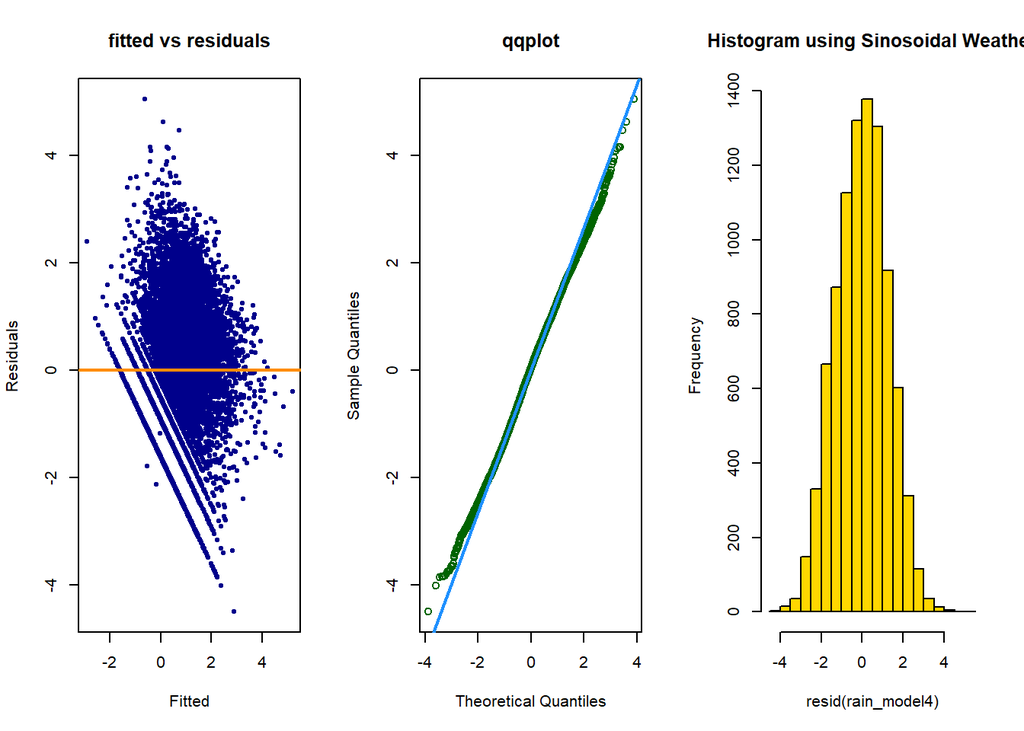

```r
get_plot("fitted vs residuals", "qqplot", rain_model4)
hist(resid(rain_model4), main="Histogram using Sinosoidal Weather", col = "gold")
```

# Results

Predicting rainfall is very difficult. We found several models that may do the job credibly. In our selected model, we state that humidity, pressure, and cloud cover all combine in intricate ways to generate the possibility of rainfall.

> lm(formula = log(Rainfall) ~ (Location + log(Evaporation + 0.1) + Sunshine + log(WindSpeed9am) + log(WindSpeed3pm) + Humidity9am + Humidity3pm + Pressure9am + Temp9am)^2 + (sin(Date * pi/6) + cos(Date * pi/6) + sin(WindDir9am * pi/8) + cos(WindDir9am * pi/8) + sin(WindDir3pm * pi/8) + cos(WindDir3pm * pi/8) + Cloud9am + I(Cloud9am^2) + I(Cloud9am^3) + Cloud3pm + I(Cloud3pm^2) + I(Cloud3pm^3)) * (Location + log(Evaporation + 0.1) + Sunshine + log(WindSpeed9am) + log(WindSpeed3pm) + Humidity9am + Humidity3pm + Pressure9am + Temp9am) + (sin(Date * pi/6) + cos(Date * pi/6)) * (sin(WindDir9am * pi/8) + cos(WindDir9am * pi/8) + sin(WindDir3pm * pi/8) + cos(WindDir3pm * pi/8) + Cloud9am + I(Cloud9am^2) + I(Cloud9am^3) + Cloud3pm + I(Cloud3pm^2) + I(Cloud3pm^3)) + (sin(WindDir9am * pi/8) + cos(WindDir9am * pi/8)) * (sin(WindDir3pm * pi/8) + cos(WindDir3pm * pi/8) + Cloud9am + I(Cloud9am^2) + I(Cloud9am^3) + Cloud3pm + I(Cloud3pm^2) + I(Cloud3pm^3)) + (sin(WindDir3pm * pi/8) + cos(WindDir3pm * pi/8)) * (Cloud9am + I(Cloud9am^2) + I(Cloud9am^3) + Cloud3pm + I(Cloud3pm^2) + I(Cloud3pm^3) + (Cloud9am + I(Cloud9am^2) + I(Cloud9am^3)) * (Cloud3pm + I(Cloud3pm^2) + I(Cloud3pm^3))), data = subset(weather_trn, rainfall > 0))

# Discussion

There are many different types of cloud cover. As such, it was necessary to provide specific higher order interactions amongst the other predictors. Wind speed and direction turned out to be a driving force as well, and mathematical sin transforms were needed to account for the direction. In order for the data to be fit properly, the log of predictors Evaporation, WindSpeed9am, and WindSpeed3pm was needed.

Predicting the weather is very hard. There are currently 15 major global and regional weather models (https://windy.app/blog/what-is-a-weather-forecast-model-guide-on-forecast-models-all-around-the-world.html), each with different inputs and mathematical computations. Our model is simple by comparison, but reacts well given the limited input and time constraints.

# Appendices

## Appendix A: Group Members

- Peter Hartman (pehartma@illinois.edu)
- Santu Banerjee (santub2@illinois.edu)
- Colton Manning (coltonm4@illinois.edu)
- Ron Hong (ronaldh3@illinois.edu)

## Appendix B: Data Curation Methods

These are the methods we used to curate the data into a useable form.

```r
library(readr)
library(MASS)

weatherAUS = subset(na.omit(read.csv("weatherAUS.csv")), select = -c(RainTomorrow))

weather1 = weatherAUS

weather1$Location[which(weather1$Location == "MelbourneAirport")] = "Melbourne"
weather1$Location[which(weather1$Location == "SydneyAirport")] = "Sydney"
weather1$Location[which(weather1$Location == "PerthAirport")] = "Perth"

wind_num = function(windDir) {
  windDir[windDir == "N"] = 0
  windDir[windDir == "NNE"] = 1
  windDir[windDir == "NE"] = 2
  windDir[windDir == "ENE"] = 3
  windDir[windDir == "E"] = 4
  windDir[windDir == "ESE"] = 5
  windDir[windDir == "SE"] = 6
  windDir[windDir == "SSE"] = 7
  windDir[windDir == "S"] = 8
  windDir[windDir == "SSW"] = 9
  windDir[windDir == "SW"] = 10
  windDir[windDir == "WSW"] = 11
  windDir[windDir == "W"] = 12
  windDir[windDir == "WNW"] = 13
  windDir[windDir == "NW"] = 14
  windDir[windDir == "NNW"] = 15
  as.numeric(windDir)
}


weather1$WindGustDir = wind_num(weather1$WindGustDir)
weather1$WindDir9am = wind_num(weather1$WindDir9am)
weather1$WindDir3pm = wind_num(weather1$WindDir3pm)

weather_subset = c()

for(loc in c("AliceSprings", "Brisbane", "Cairns", "Darwin", "Melbourne", "Mildura", "MountGambier", "NorfolkIsland", "Perth", "Sydney", "WaggaWagga", "Watsonia", "Woomera")) {
  weather_subset = rbind(weather_subset, subset(weather1, weather1$Location == loc))
  }

weather = weather_subset

weather$RainToday = as.factor(weather$RainToday)

weather$Date = lubridate::month(weather$Date)


weather$Location = as.factor(weather$Location)

set.seed(42)
trn_num = round(nrow(weather) * 0.4,0)
trn_idx = runif(trn_num, 1, nrow(weather))
# Test is 40%
weather_tst = weather[trn_idx,]
# Train is 60%
weather_trn = weather[ -trn_idx,]
```

As well as the table creation.

```r
locations = c("AliceSprings", "Brisbane", "Cairns", "Darwin", "Melbourne", "Mildura", "MountGambier", "NorfolkIsland", "Perth", "Sydney", "WaggaWagga", "Watsonia", "Woomera", "Canberra", "Cobar", "CoffsHarbour", "Hobart", "Moree", "Nuriootpa", "Portland", "Sale", "Townsville", "Williamtown" )
observations = c(2223, 2953, 2444, 3062, 4827, 2594, 2465, 2464, 5938, 4560, 2416, 2730, 1734, 1078, 534, 1380, 1939, 1913, 2008, 1863, 1678, 2419, 1198)
geography = c("Subtropical Desert", "Coastal Flatland", "Coastal Rainforest", "Coastal Flatland", "Coastal Mountain", "Flatland", "Mountain", "Island Mountain", "Coastal Flatland", "Coastal Mountain", "Flatland", "Coastal Mountain", "Desert", "Wetlands", "Semi-Arid", "Coastal Mountain", "Coastal Mountain", "Flatland", "Coastal Flatland", "Coastal Flatland", "Coastal Flatland", "Coastal Flatland", "Coastal Flatland")
Use = c("Yes", "Yes", "Yes", "Yes", "Yes", "Yes", "Yes", "Yes", "Yes", "Yes", "Yes", "Yes", "Yes", "No", "No", "No", "No", "No", "No", "No", "No", "No", "No")
Location_table = data.frame("Locations" = locations, "Observations" = observations, "Geography" = geography, "Use" = Use)
library(knitr)
kable(Location_table)
```

## Appendix C: Functions

We needed several standard functions throughout our project.

```r
# Create function to plot Fitted vs Residuals and QQ plots

get_plot = function(name_desc_fit, name_desc_qq, lm_mod){

  par(mfrow = c(1, 3))

  # Fitted vs Residuals plot
  plot(fitted(lm_mod), resid(lm_mod), col = "darkblue", pch = 20,
       xlab = "Fitted", ylab = "Residuals", main = name_desc_fit)
  abline(h = 0, col = "darkorange", lwd = 2)

  # QQ plot

  qqnorm(resid(lm_mod), main = name_desc_qq, col = "darkgreen")
  qqline(resid(lm_mod), col = "dodgerblue", lwd = 2)

}

# Function to calculate LOOCV RMSE

calc_loocv_rmse = function(model) {
  sqrt(mean((resid(model) / (1 - hatvalues(model))) ^ 2))
}

# Function to calculate RMSE

calc_RMSE = function(pred_vals, actual_vals){
  sqrt(mean((pred_vals - actual_vals) ^ 2))
}

# Write function to calculate TEST adjusted R square

test_adj_r_sqr = function(pred_val, actual_val, lm_mod){
  p = length(coef(lm_mod))
  n = length(pred_val)
  test_r_sqr = 1 - ((sum((actual_val - pred_val)^2)) /
                      (sum((actual_val - mean(actual_val))^2)))
  adj_r_sqr = 1 - (((n - 1)/(n - p)) * (1 - (test_r_sqr ^ 2)))

}

make_conf_mat = function(predicted, actual) {
table(predicted = predicted, actual = actual)
}
```

## Appendix D: Raw results from Ron

The first thing our team did was look at the multicollinarity of the data:

```r
car::vif(lm(Rainfall ~ . - RainToday, data = weather_trn))
```

```
##                    GVIF Df GVIF^(1/(2*Df))
## Date           1.196287  1        1.093749
## Location      10.579173 12        1.103279
## MinTemp       13.695194  1        3.700702
## MaxTemp       49.064025  1        7.004572
## Evaporation    2.776036  1        1.666144
## Sunshine       3.679050  1        1.918085
## WindGustDir    1.618329  1        1.272136
## WindGustSpeed  3.074494  1        1.753424
## WindDir9am     1.479945  1        1.216530
## WindDir3pm     1.615591  1        1.271059
## WindSpeed9am   2.195631  1        1.481766
## WindSpeed3pm   2.436821  1        1.561032
## Humidity9am    4.933298  1        2.221103
## Humidity3pm    7.643805  1        2.764743
## Pressure9am   26.122308  1        5.110999
## Pressure3pm   25.347068  1        5.034587
## Cloud9am       2.388682  1        1.545536
## Cloud3pm       2.385574  1        1.544530
## Temp9am       28.939869  1        5.379579
## Temp3pm       56.774205  1        7.534866
```

Pressure, Temperature, Humidity3pm, and Location all have a VIF over 5, so they are all cause for concern.

Removing those factors, excluding Location, and the VIF values are much less of a concern.

```r
car::vif(lm(Rainfall ~ . - RainToday - Humidity3pm - Pressure9am - Pressure3pm - Temp9am - Temp3pm, data = weather_trn))
```

```
##                   GVIF Df GVIF^(1/(2*Df))
## Date          1.144940  1        1.070019
## Location      6.837890 12        1.083399
## MinTemp       6.339942  1        2.517924
## MaxTemp       6.540615  1        2.557463
## Evaporation   2.721194  1        1.649604
## Sunshine      3.507465  1        1.872823
## WindGustDir   1.588375  1        1.260308
## WindGustSpeed 2.784508  1        1.668684
## WindDir9am    1.428406  1        1.195160
## WindDir3pm    1.565945  1        1.251377
## WindSpeed9am  2.109281  1        1.452336
## WindSpeed3pm  2.373105  1        1.540489
## Humidity9am   2.638255  1        1.624271
## Cloud9am      2.349865  1        1.532927
## Cloud3pm      2.277119  1        1.509013
```

When looking at the log mean of Rainfall per month, we can see when the more rainy seasons are:

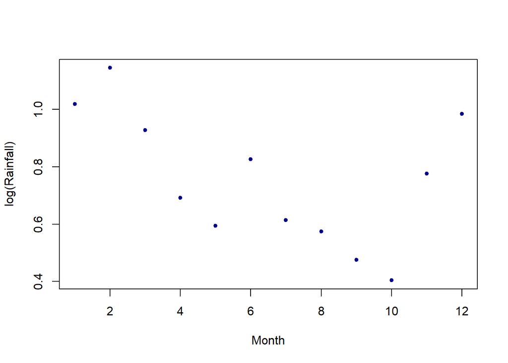

```r
meanRainfall = function(predictor) {
  meanRainfallSub = rep(0, length(unique(predictor)))
  for (i in 1:length(unique(predictor))) {
    meanRainfallSub[i] =
      mean(subset(weather_trn, predictor == unique(predictor)[i])$Rainfall)
  }
  meanRainfallSub
}

plot(
  unique(weather_trn$Date),
  log(meanRainfall(weather_trn$Date)),
  xlab = "Month",
  ylab = "log(Rainfall)",
  col = "darkblue",
  pch = 20
)
```

Next, the team tried plotting the log of rainfall vs the log of other predictors, to see if the log of the predictors fit better.

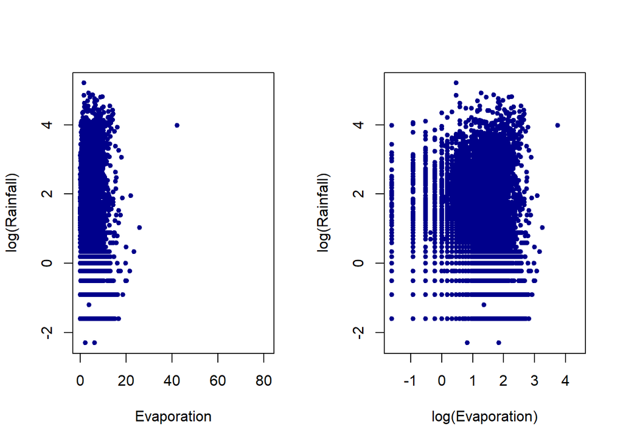

```r
par(mfrow = c(1, 2))
plot(
  log(Rainfall) ~ Evaporation,
  data = weather_trn,
  col = "darkblue",
  pch = 20
)
plot(
  log(Rainfall) ~ log(Evaporation),
  data = weather_trn,
  col = "darkblue",
  pch = 20
)
```

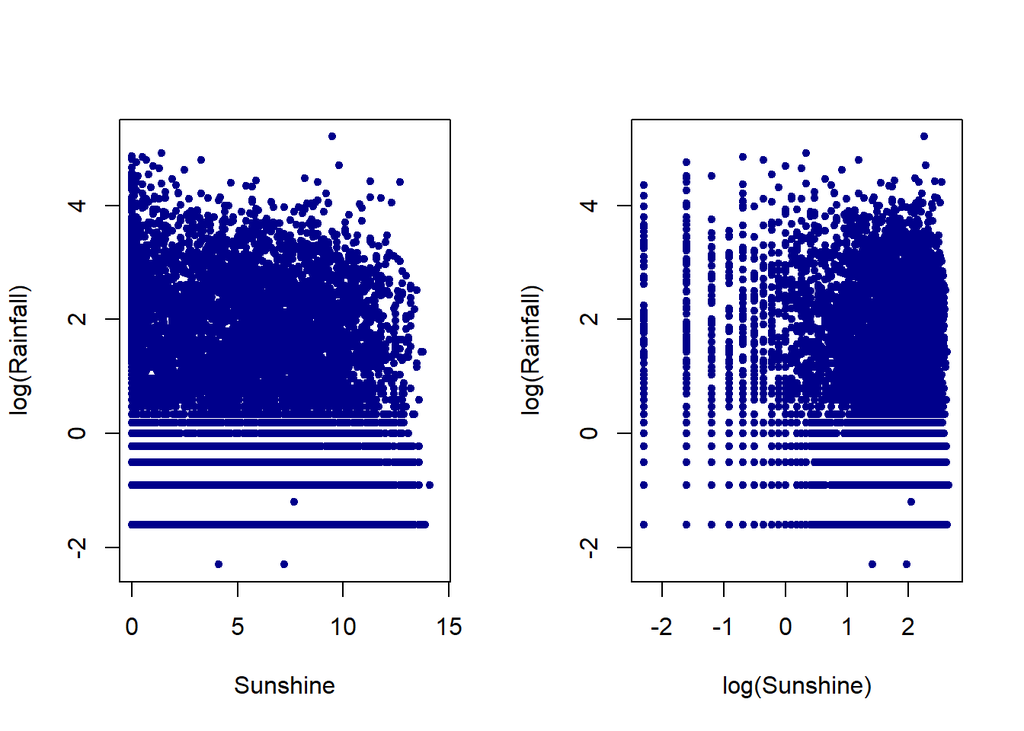

```r
par(mfrow = c(1, 2))
plot(
  log(Rainfall) ~ Sunshine,
  data = weather_trn,
  col = "darkblue",
  pch = 20
)
plot(
  log(Rainfall) ~ log(Sunshine),
  data = weather_trn,
  col = "darkblue",
  pch = 20
)
```

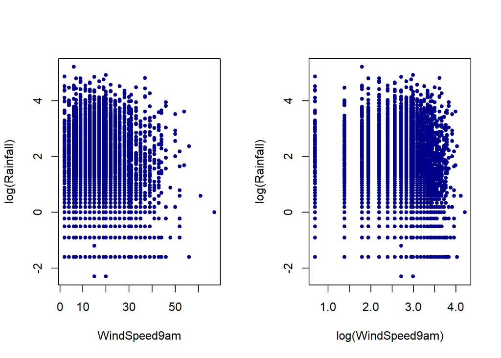

```r
par(mfrow = c(1, 2))
plot(
  log(Rainfall) ~ WindSpeed9am,
  data = weather_trn,
  col = "darkblue",
  pch = 20
)
plot(
  log(Rainfall) ~ log(WindSpeed9am),
  data = weather_trn,
  col = "darkblue",
  pch = 20
)
```

```r
par(mfrow = c(1, 2))
plot(
  log(Rainfall) ~ WindSpeed3pm,
  data = weather_trn,
  col = "darkblue",
  pch = 20
)
plot(
  log(Rainfall) ~ log(WindSpeed3pm),
  data = weather_trn,
  col = "darkblue",
  pch = 20
)
```

[output not shown]

[figure not shown]

[figure not shown]

```r
plot(log(Rainfall) ~ Temp9am, data = weather_trn)
```

[output not shown]

A backwards AIC will be applied to the following models.

log0 is undefined, and this will be addressed two separate ways. First, all 0 points will be removed from the training data, but not from the test data.

```r
rain_model = step(
  lm(
    log(Rainfall) ~ sin(Date * pi / 6) + cos(Date * pi / 6) + Location +
      log(Evaporation + 0.1) + Sunshine +
      sin(WindDir9am * pi / 8) + cos(WindDir9am * pi / 8) +
      sin(WindDir3pm * pi / 8) + cos(WindDir3pm * pi / 8) +
      log(WindSpeed9am) + log(WindSpeed3pm) + Humidity9am + Humidity3pm +
      Pressure9am + Cloud9am + Cloud3pm + Temp9am,
    data = subset(weather_trn, Rainfall > 0)
  ),
  trace = FALSE
)
```

Note that LOOCV-RMSE is not adjusted for log scale, which would be difficult given what we the shortcut method of finding LOOCV-RMSE for linear regression.

```r
summary(rain_model)$adj.r.squared
```

```
## [1] 0.2307049
```

```r
sqrt(mean((resid(rain_model) / (1 - hatvalues(rain_model))) ^ 2))
```

```
## [1] 1.373903
```

```r
sqrt(mean((weather_tst$Rainfall -
             exp(predict(rain_model, newdata = weather_tst))) ^ 2))
```

```
## [1] 6.682094
```

Looking at the Fitted vs Residuals and QQPlot:

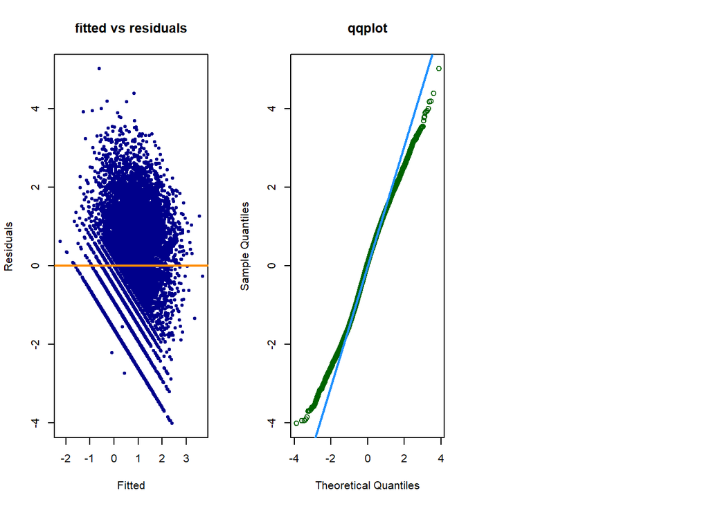

```r
get_plot("fitted vs residuals", "qqplot", rain_model)
```

Next, padding will be added to Rainfall, so there will be no 0 values.

```r
rain_model2 = step(
  lm(
    log(Rainfall + 0.1) ~ sin(Date * pi / 6) + cos(Date * pi / 6) + Location +
      log(Evaporation + 0.1) + Sunshine +
      sin(WindDir9am * pi / 8) + cos(WindDir9am * pi / 8) +
      sin(WindDir3pm * pi / 8) + cos(WindDir3pm * pi / 8) +
      log(WindSpeed9am) + log(WindSpeed3pm) + Humidity9am + Humidity3pm +
      Pressure9am + Cloud9am + Cloud3pm + Temp9am,
    data = weather_trn
  ),
  trace = FALSE
)
```

```r
summary(rain_model2)$adj.r.squared
```

```
## [1] 0.3632751
```

```r
sqrt(mean((resid(rain_model2) / (1 - hatvalues(rain_model2))) ^ 2))
```

```
## [1] 1.376286
```

```r
sqrt(mean((weather_tst$Rainfall -
             (exp(predict(rain_model2, newdata = weather_tst)) - 0.1)) ^ 2))
```

```
## [1] 7.240344
```

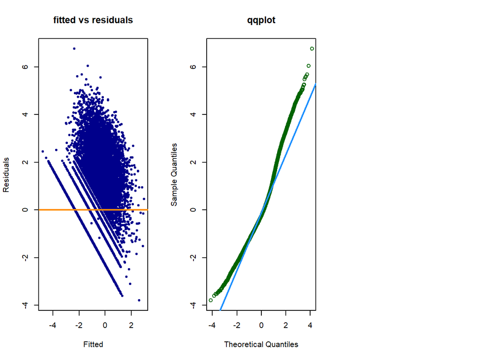

```r
get_plot("fitted vs residuals", "qqplot", rain_model2)
```

It appears that the cloudiness variables might have a cubic relationship with rainfall.

```r
rain_model3 = step(
  lm(
    log(Rainfall) ~ sin(Date * pi / 6) + cos(Date * pi / 6) + Location +
      log(Evaporation + 0.1) + Sunshine +
      sin(WindDir9am * pi / 8) + cos(WindDir9am * pi / 8) +
      sin(WindDir3pm * pi / 8) + cos(WindDir3pm * pi / 8) +
      log(WindSpeed9am) + log(WindSpeed3pm) + Humidity9am + Humidity3pm +
      Pressure9am + Cloud9am + I(Cloud9am ^ 2) + I(Cloud9am ^ 3) +
      Cloud3pm + I(Cloud3pm ^ 2) + I(Cloud3pm ^ 3) + Temp9am,
    data = subset(weather_trn, Rainfall > 0)
  ),
  trace = FALSE
)
```

```r
summary(rain_model3)$adj.r.squared
```

```
## [1] 0.232392
```

```r
sqrt(mean((resid(rain_model3) / (1 - hatvalues(rain_model3))) ^ 2))
```

```
## [1] 1.372774
```

```r
sqrt(mean((weather_tst$Rainfall -
             (exp(predict(rain_model3, newdata = weather_tst)) - 0.1)) ^ 2))
```

```
## [1] 6.683764
```

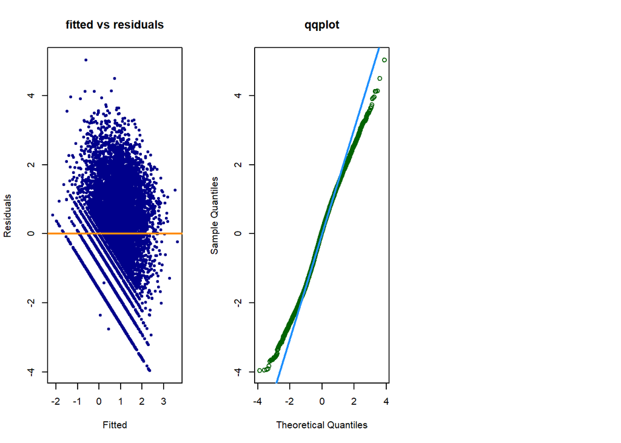

```r
get_plot("fitted vs residuals", "qqplot", rain_model3)
```

Next, an interaction model is used.

```r
rain_model4 = lm(
  log(Rainfall) ~ (
    Location + log(Evaporation + 0.1) + Sunshine +
      log(WindSpeed9am) + log(WindSpeed3pm) + Humidity9am + Humidity3pm +
      Pressure9am + Temp9am
  ) ^ 2 + (
    sin(Date * pi / 6) + cos(Date * pi / 6) +
      sin(WindDir9am * pi / 8) + cos(WindDir9am * pi / 8) +
      sin(WindDir3pm * pi / 8) + cos(WindDir3pm * pi / 8) +
      Cloud9am + I(Cloud9am ^ 2) + I(Cloud9am ^ 3) +
      Cloud3pm + I(Cloud3pm ^ 2) + I(Cloud3pm ^ 3)
  ) * (
    Location + log(Evaporation + 0.1) + Sunshine +
      log(WindSpeed9am) + log(WindSpeed3pm) + Humidity9am + Humidity3pm +
      Pressure9am + Temp9am
  ) + (sin(Date * pi / 6) + cos(Date * pi / 6)) * (
    sin(WindDir9am * pi / 8) + cos(WindDir9am * pi / 8) +
      sin(WindDir3pm * pi / 8) + cos(WindDir3pm * pi / 8) +
      Cloud9am + I(Cloud9am ^ 2) + I(Cloud9am ^ 3) +
      Cloud3pm + I(Cloud3pm ^ 2) + I(Cloud3pm ^ 3)
  ) + (sin(WindDir9am * pi / 8) + cos(WindDir9am * pi / 8)) * (
    sin(WindDir3pm * pi / 8) + cos(WindDir3pm * pi / 8) +
      Cloud9am + I(Cloud9am ^ 2) + I(Cloud9am ^ 3) +
      Cloud3pm + I(Cloud3pm ^ 2) + I(Cloud3pm ^ 3)
  ) + (sin(WindDir3pm * pi / 8) + cos(WindDir3pm * pi / 8)) * (
    Cloud9am + I(Cloud9am ^ 2) + I(Cloud9am ^ 3) +
      Cloud3pm + I(Cloud3pm ^ 2) + I(Cloud3pm ^ 3) +
      (Cloud9am + I(Cloud9am ^ 2) + I(Cloud9am ^ 3)) *
      (Cloud3pm + I(Cloud3pm ^ 2) + I(Cloud3pm ^ 3))
  ),
  data = subset(weather_trn, Rainfall > 0)
)
```

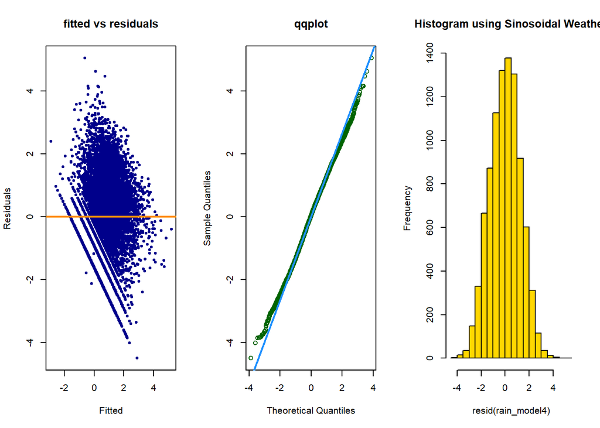

```r
get_plot("fitted vs residuals", "qqplot", rain_model4)
hist(resid(rain_model4), main="Histogram using Sinosoidal Weather", col = "gold")
```

## Appendix E: Raw results from Colton

### Additive only

##### Exhaustive search

```r
library(leaps)
#models = summary(regsubsets(Rainfall ~ ., data = weather_sub, really.big = TRUE))
#models
```

##### Forward search

```r
mod_start = lm(Rainfall ~ 1, data = weather_trn)
forward_AIC = step(mod_start, scope = Rainfall ~ Date + Location + Evaporation + Sunshine + Humidity9am + Pressure9am + Cloud9am + Temp9am + RainToday, direction = "forward", trace = 0)
forward_BIC = step(mod_start, scope = Rainfall ~ Date + Location + Evaporation + Sunshine + Humidity9am + Pressure9am + Cloud9am + Temp9am + RainToday, direction = "forward", trace = 0, k = log(nrow(weather_trn)))
```

```r
summary(forward_AIC)$call
```

```
## lm(formula = Rainfall ~ RainToday + Location + Sunshine + Pressure9am +
##     Humidity9am + Evaporation + Date + Temp9am, data = weather_trn)
```

```r
forward_AIC$anova
```

```
##            Step  Df    Deviance Resid. Df Resid. Dev       AIC
## 1                NA          NA     27036  1395358.9 106627.83
## 2   + RainToday  -1 426223.4606     27035   969135.5  96774.78
## 3    + Location -12  12353.9252     27023   956781.5  96451.91
## 4    + Sunshine  -1  10498.6750     27022   946282.9  96155.60
## 5 + Pressure9am  -1   7679.3734     27021   938603.5  95937.29
## 6 + Humidity9am  -1   4745.5902     27020   933857.9  95802.24
## 7 + Evaporation  -1   5271.3644     27019   928586.5  95651.20
## 8        + Date  -1    223.1593     27018   928363.4  95646.70
## 9     + Temp9am  -1    310.2231     27017   928053.2  95639.66
```

```r
summary(forward_BIC)$call
```

```
## lm(formula = Rainfall ~ RainToday + Pressure9am + Humidity9am +
##     Location + Sunshine + Evaporation, data = weather_trn)
```

```r
forward_BIC$anova
```

```
##            Step  Df   Deviance Resid. Df Resid. Dev       AIC
## 1                NA         NA     27036  1395358.9 106636.04
## 2   + RainToday  -1 426223.461     27035   969135.5  96791.19
## 3 + Pressure9am  -1  11566.582     27034   957568.9  96476.77
## 4 + Humidity9am  -1   8568.753     27033   949000.1  96243.94
## 5    + Location -12  11081.181     27021   937918.9  96048.84
## 6    + Sunshine  -1   4061.047     27020   933857.9  95941.73
## 7 + Evaporation  -1   5271.364     27019   928586.5  95798.88
```

```r
forward_AIC$anova
```

```
##            Step  Df    Deviance Resid. Df Resid. Dev       AIC
## 1                NA          NA     27036  1395358.9 106627.83
## 2   + RainToday  -1 426223.4606     27035   969135.5  96774.78
## 3    + Location -12  12353.9252     27023   956781.5  96451.91
## 4    + Sunshine  -1  10498.6750     27022   946282.9  96155.60
## 5 + Pressure9am  -1   7679.3734     27021   938603.5  95937.29
## 6 + Humidity9am  -1   4745.5902     27020   933857.9  95802.24
## 7 + Evaporation  -1   5271.3644     27019   928586.5  95651.20
## 8        + Date  -1    223.1593     27018   928363.4  95646.70
## 9     + Temp9am  -1    310.2231     27017   928053.2  95639.66
```

```r
forward_BIC$anova
```

```
##            Step  Df   Deviance Resid. Df Resid. Dev       AIC
## 1                NA         NA     27036  1395358.9 106636.04
## 2   + RainToday  -1 426223.461     27035   969135.5  96791.19
## 3 + Pressure9am  -1  11566.582     27034   957568.9  96476.77
## 4 + Humidity9am  -1   8568.753     27033   949000.1  96243.94
## 5    + Location -12  11081.181     27021   937918.9  96048.84
## 6    + Sunshine  -1   4061.047     27020   933857.9  95941.73
## 7 + Evaporation  -1   5271.364     27019   928586.5  95798.88
```

##### Backward search

```r
mod_start_bkw = lm(Rainfall ~ ., data = weather_trn)
backward_AIC = step(mod_start_bkw, direction = "backward", trace = 0)
backward_BIC = step(mod_start_bkw, direction = "backward", k = log(nrow(weather_trn)), trace = 0)
```

```r
summary(backward_AIC)$call
```

```
## lm(formula = Rainfall ~ Date + Location + MinTemp + MaxTemp +
##     Evaporation + Sunshine + WindGustSpeed + WindDir3pm + WindSpeed9am +
##     WindSpeed3pm + Humidity9am + Humidity3pm + Pressure9am +
##     Pressure3pm + Cloud9am + Cloud3pm + Temp9am + Temp3pm + RainToday,
##     data = weather_trn)
```

```r
backward_AIC$anova
```

```
##            Step Df  Deviance Resid. Df Resid. Dev      AIC
## 1               NA        NA     27004   917889.0 95367.91
## 2 - WindGustDir  1  4.555415     27005   917893.5 95366.05
## 3  - WindDir9am  1 12.530638     27006   917906.0 95364.42
```

```r
summary(backward_BIC)$call
```

```
## lm(formula = Rainfall ~ Location + MinTemp + MaxTemp + Evaporation +
##     Sunshine + WindGustSpeed + WindSpeed3pm + Humidity9am + Humidity3pm +
##     Pressure9am + Pressure3pm + Cloud3pm + Temp3pm + RainToday,
##     data = weather_trn)
```

```r
backward_BIC$anova
```

```
##             Step Df   Deviance Resid. Df Resid. Dev      AIC
## 1                NA         NA     27004   917889.0 95638.68
## 2  - WindGustDir  1   4.555415     27005   917893.5 95628.61
## 3   - WindDir9am  1  12.530638     27006   917906.0 95618.77
## 4   - WindDir3pm  1  95.808258     27007   918001.8 95611.39
## 5      - Temp9am  1 123.979984     27008   918125.8 95604.83
## 6     - Cloud9am  1 229.315550     27009   918355.1 95601.38
## 7         - Date  1 196.229691     27010   918551.4 95596.95
## 8 - WindSpeed9am  1 330.994362     27011   918882.4 95596.49
```

```r
backward_AIC$anova
```

```
##            Step Df  Deviance Resid. Df Resid. Dev      AIC
## 1               NA        NA     27004   917889.0 95367.91
## 2 - WindGustDir  1  4.555415     27005   917893.5 95366.05
## 3  - WindDir9am  1 12.530638     27006   917906.0 95364.42
```

```r
backward_BIC$anova
```

```
##             Step Df   Deviance Resid. Df Resid. Dev      AIC
## 1                NA         NA     27004   917889.0 95638.68
## 2  - WindGustDir  1   4.555415     27005   917893.5 95628.61
## 3   - WindDir9am  1  12.530638     27006   917906.0 95618.77
## 4   - WindDir3pm  1  95.808258     27007   918001.8 95611.39
## 5      - Temp9am  1 123.979984     27008   918125.8 95604.83
## 6     - Cloud9am  1 229.315550     27009   918355.1 95601.38
## 7         - Date  1 196.229691     27010   918551.4 95596.95
## 8 - WindSpeed9am  1 330.994362     27011   918882.4 95596.49
```

##### Stepwise search

```r
mod_start = lm(Rainfall ~ 1, data = weather_trn)
stepwise_AIC = step(mod_start, scope = Rainfall ~ Date + Location + Evaporation + Sunshine + Humidity9am + Pressure9am + Cloud9am + Temp9am + RainToday, direction = "both", trace = 0)
stepwise_BIC = step(mod_start, scope = Rainfall ~ Date + Location + Evaporation + Sunshine + Humidity9am + Pressure9am + Cloud9am + Temp9am + RainToday, direction = "both", trace = 0, k = log(nrow(weather_trn)))
```

```r
summary(stepwise_AIC)$call
```

```
## lm(formula = Rainfall ~ RainToday + Location + Sunshine + Pressure9am +
##     Humidity9am + Evaporation + Date + Temp9am, data = weather_trn)
```

```r
stepwise_AIC$anova
```

```
##            Step  Df    Deviance Resid. Df Resid. Dev       AIC
## 1                NA          NA     27036  1395358.9 106627.83
## 2   + RainToday  -1 426223.4606     27035   969135.5  96774.78
## 3    + Location -12  12353.9252     27023   956781.5  96451.91
## 4    + Sunshine  -1  10498.6750     27022   946282.9  96155.60
## 5 + Pressure9am  -1   7679.3734     27021   938603.5  95937.29
## 6 + Humidity9am  -1   4745.5902     27020   933857.9  95802.24
## 7 + Evaporation  -1   5271.3644     27019   928586.5  95651.20
## 8        + Date  -1    223.1593     27018   928363.4  95646.70
## 9     + Temp9am  -1    310.2231     27017   928053.2  95639.66
```

```r
summary(stepwise_BIC)$call
```

```
## lm(formula = Rainfall ~ RainToday + Pressure9am + Humidity9am +
##     Location + Sunshine + Evaporation, data = weather_trn)
```

```r
stepwise_BIC$anova
```

```
##            Step  Df   Deviance Resid. Df Resid. Dev       AIC
## 1                NA         NA     27036  1395358.9 106636.04
## 2   + RainToday  -1 426223.461     27035   969135.5  96791.19
## 3 + Pressure9am  -1  11566.582     27034   957568.9  96476.77
## 4 + Humidity9am  -1   8568.753     27033   949000.1  96243.94
## 5    + Location -12  11081.181     27021   937918.9  96048.84
## 6    + Sunshine  -1   4061.047     27020   933857.9  95941.73
## 7 + Evaporation  -1   5271.364     27019   928586.5  95798.88
```

```r
stepwise_AIC$anova
```

```
##            Step  Df    Deviance Resid. Df Resid. Dev       AIC
## 1                NA          NA     27036  1395358.9 106627.83
## 2   + RainToday  -1 426223.4606     27035   969135.5  96774.78
## 3    + Location -12  12353.9252     27023   956781.5  96451.91
## 4    + Sunshine  -1  10498.6750     27022   946282.9  96155.60
## 5 + Pressure9am  -1   7679.3734     27021   938603.5  95937.29
## 6 + Humidity9am  -1   4745.5902     27020   933857.9  95802.24
## 7 + Evaporation  -1   5271.3644     27019   928586.5  95651.20
## 8        + Date  -1    223.1593     27018   928363.4  95646.70
## 9     + Temp9am  -1    310.2231     27017   928053.2  95639.66
```

```r
stepwise_BIC$anova
```

```
##            Step  Df   Deviance Resid. Df Resid. Dev       AIC
## 1                NA         NA     27036  1395358.9 106636.04
## 2   + RainToday  -1 426223.461     27035   969135.5  96791.19
## 3 + Pressure9am  -1  11566.582     27034   957568.9  96476.77
## 4 + Humidity9am  -1   8568.753     27033   949000.1  96243.94
## 5    + Location -12  11081.181     27021   937918.9  96048.84
## 6    + Sunshine  -1   4061.047     27020   933857.9  95941.73
## 7 + Evaporation  -1   5271.364     27019   928586.5  95798.88
```

##### Models

```r
forward_AIC$call
```

```
## lm(formula = Rainfall ~ RainToday + Location + Sunshine + Pressure9am +
##     Humidity9am + Evaporation + Date + Temp9am, data = weather_trn)
```

```r
forward_BIC$call
```

```
## lm(formula = Rainfall ~ RainToday + Pressure9am + Humidity9am +
##     Location + Sunshine + Evaporation, data = weather_trn)
```

```r
forward_AIC$call == forward_BIC$call
```

```
## [1] FALSE
```

```r
backward_AIC$call
```

```
## lm(formula = Rainfall ~ Date + Location + MinTemp + MaxTemp +
##     Evaporation + Sunshine + WindGustSpeed + WindDir3pm + WindSpeed9am +
##     WindSpeed3pm + Humidity9am + Humidity3pm + Pressure9am +
##     Pressure3pm + Cloud9am + Cloud3pm + Temp9am + Temp3pm + RainToday,
##     data = weather_trn)
```

```r
backward_BIC$call
```

```
## lm(formula = Rainfall ~ Location + MinTemp + MaxTemp + Evaporation +
##     Sunshine + WindGustSpeed + WindSpeed3pm + Humidity9am + Humidity3pm +
##     Pressure9am + Pressure3pm + Cloud3pm + Temp3pm + RainToday,
##     data = weather_trn)
```

```r
backward_AIC$call == backward_BIC$call
```

```
## [1] FALSE
```

```r
stepwise_AIC$call
```

```
## lm(formula = Rainfall ~ RainToday + Location + Sunshine + Pressure9am +
##     Humidity9am + Evaporation + Date + Temp9am, data = weather_trn)
```

```r
stepwise_BIC$call
```

```
## lm(formula = Rainfall ~ RainToday + Pressure9am + Humidity9am +
##     Location + Sunshine + Evaporation, data = weather_trn)
```

```r
stepwise_AIC$call == stepwise_BIC$call
```

```
## [1] FALSE
```

```r
forward_AIC$anova$AIC[length(forward_AIC$anova$AIC)]
```

```
## [1] 95639.66
```

```r
forward_BIC$anova$AIC[length(forward_BIC$anova$AIC)]
```

```
## [1] 95798.88
```

```r
backward_AIC$anova$AIC[length(backward_AIC$anova$AIC)]
```

```
## [1] 95364.42
```

```r
backward_BIC$anova$AIC[length(backward_BIC$anova$AIC)]
```

```
## [1] 95596.49
```

```r
stepwise_AIC$anova$AIC[length(stepwise_AIC$anova$AIC)]
```

```
## [1] 95639.66
```

```r
stepwise_BIC$anova$AIC[length(stepwise_BIC$anova$AIC)]
```

```
## [1] 95798.88
```

##### Calculating LOOCV RMSE on train data

```r
calc_loocv_rmse = function(model) {
  sqrt(mean((resid(model) / (1 - hatvalues(model))) ^ 2))
}
```

```r
forward_AIC_RMSE_loocv = calc_loocv_rmse(forward_AIC)
forward_BIC_RMSE_loocv = calc_loocv_rmse(forward_BIC)
forward_AIC_RMSE_loocv
```

```
## [1] 5.864218
```

```r
forward_BIC_RMSE_loocv
```

```
## [1] 5.86534
```

```r
backward_AIC_RMSE_loocv = calc_loocv_rmse(backward_AIC)
backward_BIC_RMSE_loocv = calc_loocv_rmse(backward_BIC)
backward_AIC_RMSE_loocv
```

```
## [1] 5.834493
```

```r
backward_BIC_RMSE_loocv
```

```
## [1] 5.836562
```

```r
stepwise_AIC_RMSE_loocv = calc_loocv_rmse(stepwise_AIC)
stepwise_BIC_RMSE_loocv = calc_loocv_rmse(stepwise_BIC)
stepwise_AIC_RMSE_loocv
```

```
## [1] 5.864218
```

```r
stepwise_BIC_RMSE_loocv
```

```
## [1] 5.86534
```

##### Calculating RMSE on test data

```r
forward_AIC_RMSE = sqrt(mean((weather_tst$Rainfall - predict(forward_AIC, newdata = weather_tst)) ^ 2))
forward_BIC_RMSE = sqrt(mean((weather_tst$Rainfall - predict(forward_BIC, newdata = weather_tst)) ^ 2))
forward_AIC_RMSE
```

```
## [1] 6.063387
```

```r
forward_BIC_RMSE
```

```
## [1] 6.063625
```

```r
backward_AIC_RMSE = sqrt(mean((weather_tst$Rainfall - predict(backward_AIC, newdata = weather_tst)) ^ 2))
backward_BIC_RMSE = sqrt(mean((weather_tst$Rainfall - predict(backward_BIC, newdata = weather_tst)) ^ 2))
backward_AIC_RMSE
```

```
## [1] 6.029268
```

```r
backward_BIC_RMSE
```

```
## [1] 6.032952
```

```r
stepwise_AIC_RMSE = sqrt(mean((weather_tst$Rainfall - predict(stepwise_AIC, newdata = weather_tst)) ^ 2))
stepwise_BIC_RMSE = sqrt(mean((weather_tst$Rainfall - predict(stepwise_BIC, newdata = weather_tst)) ^ 2))
stepwise_AIC_RMSE
```

```
## [1] 6.063387
```

```r
stepwise_BIC_RMSE
```

```
## [1] 6.063625
```

##### Adjusted $R^2$

```r
forward_AIC_adj_r_sq = test_adj_r_sqr(pred_val = predict(forward_AIC, newdata = weather_tst), actual_val = weather_tst$Rainfall, lm_mod = forward_AIC)
forward_BIC_adj_r_sq = test_adj_r_sqr(pred_val = predict(forward_BIC, newdata = weather_tst), actual_val = weather_tst$Rainfall, lm_mod = forward_BIC)

backward_AIC_adj_r_sq = test_adj_r_sqr(pred_val = predict(backward_AIC, newdata = weather_tst), actual_val = weather_tst$Rainfall, lm_mod = backward_AIC)
backward_BIC_adj_r_sq = test_adj_r_sqr(pred_val = predict(backward_BIC, newdata = weather_tst), actual_val = weather_tst$Rainfall, lm_mod = backward_BIC)

stepwise_AIC_adj_r_sq = test_adj_r_sqr(pred_val = predict(stepwise_AIC, newdata = weather_tst), actual_val = weather_tst$Rainfall, lm_mod = stepwise_AIC)
stepwise_BIC_adj_r_sq = test_adj_r_sqr(pred_val = predict(stepwise_BIC, newdata = weather_tst), actual_val = weather_tst$Rainfall, lm_mod = stepwise_BIC)
```

##### Results

```r
df_table = data.frame(RSME_loocv = c(forward_AIC_RMSE_loocv, forward_BIC_RMSE_loocv, backward_AIC_RMSE_loocv, backward_BIC_RMSE_loocv, stepwise_AIC_RMSE_loocv, stepwise_BIC_RMSE_loocv),
                      RMSE_test = c(forward_AIC_RMSE, forward_BIC_RMSE, backward_AIC_RMSE, backward_BIC_RMSE, stepwise_AIC_RMSE, stepwise_BIC_RMSE),
                      adjusted_r_squared = c(forward_AIC_adj_r_sq, forward_BIC_adj_r_sq, backward_AIC_adj_r_sq, backward_BIC_adj_r_sq, stepwise_AIC_adj_r_sq, stepwise_BIC_adj_r_sq),
                      model_call = c(toString(forward_AIC$call), toString(forward_BIC$call), toString(backward_AIC$call), toString(backward_BIC$call), toString(stepwise_AIC$call), toString(stepwise_BIC$call)),
                      row.names = c("forward_AIC", "forward_BIC", "backward_AIC", "backward_BIC", "stepwise_AIC", "stepwise_BIC"))
df_table
```

```
##              RSME_loocv RMSE_test adjusted_r_squared
## forward_AIC    5.864218  6.063387          0.1004153
## forward_BIC    5.865340  6.063625          0.1004926
## backward_AIC   5.834493  6.029268          0.1047418
## backward_BIC   5.836562  6.032952          0.1044817
## stepwise_AIC   5.864218  6.063387          0.1004153
## stepwise_BIC   5.865340  6.063625          0.1004926
##                                                                                                                                                                                                                                                                     model_call
## forward_AIC                                                                                                                                             lm, Rainfall ~ RainToday + Location + Sunshine + Pressure9am + Humidity9am + Evaporation + Date + Temp9am, weather_trn
## forward_BIC                                                                                                                                                              lm, Rainfall ~ RainToday + Pressure9am + Humidity9am + Location + Sunshine + Evaporation, weather_trn
## backward_AIC lm, Rainfall ~ Date + Location + MinTemp + MaxTemp + Evaporation + Sunshine + WindGustSpeed + WindDir3pm + WindSpeed9am + WindSpeed3pm + Humidity9am + Humidity3pm + Pressure9am + Pressure3pm + Cloud9am + Cloud3pm + Temp9am + Temp3pm + RainToday, weather_trn
## backward_BIC                                                         lm, Rainfall ~ Location + MinTemp + MaxTemp + Evaporation + Sunshine + WindGustSpeed + WindSpeed3pm + Humidity9am + Humidity3pm + Pressure9am + Pressure3pm + Cloud3pm + Temp3pm + RainToday, weather_trn
## stepwise_AIC                                                                                                                                            lm, Rainfall ~ RainToday + Location + Sunshine + Pressure9am + Humidity9am + Evaporation + Date + Temp9am, weather_trn
## stepwise_BIC                                                                                                                                                             lm, Rainfall ~ RainToday + Pressure9am + Humidity9am + Location + Sunshine + Evaporation, weather_trn
```

```r
knitr::kable(df_table)
```

[output not shown]

### Additive and Interaction

##### Exhaustive search

```r
library(leaps)
#models = summary(regsubsets(Rainfall ~ ., data = weather_sub, really.big = TRUE))
#models
```

##### Forward search

```r
mod_start = lm(Rainfall ~ 1, data = weather_trn)
forward_AIC_int = step(mod_start, scope = Rainfall ~ (Evaporation + Sunshine + Humidity9am + Pressure9am + Cloud9am + Temp9am + RainToday + Date) * Location, direction = "forward", trace = 0)
forward_BIC_int = step(mod_start, scope = Rainfall ~ (Evaporation + Sunshine + Humidity9am + Pressure9am + Cloud9am + Temp9am + RainToday + Date) * Location, direction = "forward", trace = 0, k = log(nrow(weather_trn)))
```

```r
summary(forward_AIC_int)$call
```

```
## lm(formula = Rainfall ~ RainToday + Location + Sunshine + Pressure9am +
##     Humidity9am + Evaporation + Temp9am + Cloud9am + Date + RainToday:Location +
##     Location:Sunshine + Location:Pressure9am + Location:Evaporation +
##     Location:Temp9am + Location:Humidity9am + Location:Cloud9am +
##     Location:Date, data = weather_trn)
```

```r
forward_AIC_int$anova
```

```
##                      Step  Df    Deviance Resid. Df Resid. Dev       AIC
## 1                          NA          NA     27036  1395358.9 106627.83
## 2             + RainToday  -1 426223.4606     27035   969135.5  96774.78
## 3              + Location -12  12353.9252     27023   956781.5  96451.91
## 4    + RainToday:Location -12  37652.9445     27011   919128.6  95390.40
## 5              + Sunshine  -1   8308.3249     27010   910820.3  95146.89
## 6     + Sunshine:Location -12  13029.9418     26998   897790.3  94781.32
## 7           + Pressure9am  -1   7613.8137     26997   890176.5  94553.05
## 8           + Humidity9am  -1   4866.3285     26996   885310.2  94406.84
## 9  + Pressure9am:Location -12   4142.1303     26984   881168.1  94304.05
## 10          + Evaporation  -1   3238.6155     26983   877929.4  94206.49
## 11 + Evaporation:Location -12   8071.9720     26971   869857.5  93980.75
## 12              + Temp9am  -1   2054.1319     26970   867803.3  93918.83
## 13     + Temp9am:Location -12  12847.1731     26958   854956.2  93539.58
## 14 + Humidity9am:Location -12   5204.9346     26946   849751.2  93398.47
## 15             + Cloud9am  -1    201.5472     26945   849549.7  93394.06
## 16    + Cloud9am:Location -12    870.8899     26933   848678.8  93390.33
## 17                 + Date  -1     71.9595     26932   848606.8  93390.04
## 18        + Date:Location -12   1139.5229     26920   847467.3  93377.71
```

```r
summary(forward_BIC_int)$call
```

```
## lm(formula = Rainfall ~ RainToday + Pressure9am + Humidity9am +
##     Location + Sunshine + Evaporation + Temp9am + RainToday:Location +
##     Location:Sunshine + Location:Evaporation + Pressure9am:Location +
##     Location:Temp9am + Humidity9am:Location, data = weather_trn)
```

```r
forward_BIC_int$anova
```

```
##                      Step  Df   Deviance Resid. Df Resid. Dev       AIC
## 1                          NA         NA     27036  1395358.9 106636.04
## 2             + RainToday  -1 426223.461     27035   969135.5  96791.19
## 3           + Pressure9am  -1  11566.582     27034   957568.9  96476.77
## 4           + Humidity9am  -1   8568.753     27033   949000.1  96243.94
## 5              + Location -12  11081.181     27021   937918.9  96048.84
## 6    + RainToday:Location -12  37765.150     27009   900153.8  95060.14
## 7              + Sunshine  -1   2814.963     27008   897338.8  94985.66
## 8     + Sunshine:Location -12  12028.649     26996   885310.2  94743.24
## 9           + Evaporation  -1   2727.910     26995   882582.3  94670.01
## 10 + Evaporation:Location -12   7760.625     26983   874821.7  94553.68
## 11 + Pressure9am:Location -12   4964.183     26971   869857.5  94522.28
## 12              + Temp9am  -1   2054.132     26970   867803.3  94468.56
## 13     + Temp9am:Location -12  12847.173     26958   854956.2  94187.77
## 14 + Humidity9am:Location -12   5204.935     26946   849751.2  94145.13
```

```r
forward_AIC_int$anova
```

```
##                      Step  Df    Deviance Resid. Df Resid. Dev       AIC
## 1                          NA          NA     27036  1395358.9 106627.83
## 2             + RainToday  -1 426223.4606     27035   969135.5  96774.78
## 3              + Location -12  12353.9252     27023   956781.5  96451.91
## 4    + RainToday:Location -12  37652.9445     27011   919128.6  95390.40
## 5              + Sunshine  -1   8308.3249     27010   910820.3  95146.89
## 6     + Sunshine:Location -12  13029.9418     26998   897790.3  94781.32
## 7           + Pressure9am  -1   7613.8137     26997   890176.5  94553.05
## 8           + Humidity9am  -1   4866.3285     26996   885310.2  94406.84
## 9  + Pressure9am:Location -12   4142.1303     26984   881168.1  94304.05
## 10          + Evaporation  -1   3238.6155     26983   877929.4  94206.49
## 11 + Evaporation:Location -12   8071.9720     26971   869857.5  93980.75
## 12              + Temp9am  -1   2054.1319     26970   867803.3  93918.83
## 13     + Temp9am:Location -12  12847.1731     26958   854956.2  93539.58
## 14 + Humidity9am:Location -12   5204.9346     26946   849751.2  93398.47
## 15             + Cloud9am  -1    201.5472     26945   849549.7  93394.06
## 16    + Cloud9am:Location -12    870.8899     26933   848678.8  93390.33
## 17                 + Date  -1     71.9595     26932   848606.8  93390.04
## 18        + Date:Location -12   1139.5229     26920   847467.3  93377.71
```

```r
forward_BIC_int$anova
```

```
##                      Step  Df   Deviance Resid. Df Resid. Dev       AIC
## 1                          NA         NA     27036  1395358.9 106636.04
## 2             + RainToday  -1 426223.461     27035   969135.5  96791.19
## 3           + Pressure9am  -1  11566.582     27034   957568.9  96476.77
## 4           + Humidity9am  -1   8568.753     27033   949000.1  96243.94
## 5              + Location -12  11081.181     27021   937918.9  96048.84
## 6    + RainToday:Location -12  37765.150     27009   900153.8  95060.14
## 7              + Sunshine  -1   2814.963     27008   897338.8  94985.66
## 8     + Sunshine:Location -12  12028.649     26996   885310.2  94743.24
## 9           + Evaporation  -1   2727.910     26995   882582.3  94670.01
## 10 + Evaporation:Location -12   7760.625     26983   874821.7  94553.68
## 11 + Pressure9am:Location -12   4964.183     26971   869857.5  94522.28
## 12              + Temp9am  -1   2054.132     26970   867803.3  94468.56
## 13     + Temp9am:Location -12  12847.173     26958   854956.2  94187.77
## 14 + Humidity9am:Location -12   5204.935     26946   849751.2  94145.13
```

##### Backward search

```r
mod_start = lm(Rainfall ~ (Date + Evaporation + Sunshine + Humidity9am + Pressure9am + Cloud9am + Temp9am + RainToday) * Location, data = weather_trn)
backward_AIC_int = step(mod_start, direction = "backward", trace = 0)
backward_BIC_int = step(mod_start, direction = "backward", k = log(nrow(weather_trn)), trace = 0)
```

```r
summary(backward_AIC_int)$call
```

```
## lm(formula = Rainfall ~ (Date + Evaporation + Sunshine + Humidity9am +
##     Pressure9am + Cloud9am + Temp9am + RainToday) * Location,
##     data = weather_trn)
```

```r
backward_AIC_int$anova
```

```
##   Step Df Deviance Resid. Df Resid. Dev      AIC
## 1      NA       NA     26920   847467.3 93377.71
```

```r
summary(backward_BIC_int)$call
```

```
## lm(formula = Rainfall ~ Evaporation + Sunshine + Humidity9am +
##     Pressure9am + Temp9am + RainToday + Location + Evaporation:Location +
##     Humidity9am:Location + Pressure9am:Location + Temp9am:Location +
##     RainToday:Location, data = weather_trn)
```

```r
backward_BIC_int$anova
```

```
##                  Step Df  Deviance Resid. Df Resid. Dev      AIC
## 1                     NA        NA     26920   847467.3 94337.69
## 2 - Cloud9am:Location 12  849.1050     26932   848316.4 94242.30
## 3     - Date:Location 12 1151.1240     26944   849467.5 94156.51
## 4 - Sunshine:Location 12 2507.3738     26956   851974.9 94113.74
## 5              - Date  1  107.0565     26957   852082.0 94106.93
## 6          - Cloud9am  1  229.7246     26958   852311.7 94104.01
```

```r
backward_AIC_int$anova
```

```
##   Step Df Deviance Resid. Df Resid. Dev      AIC
## 1      NA       NA     26920   847467.3 93377.71
```

```r
backward_BIC_int$anova
```

```
##                  Step Df  Deviance Resid. Df Resid. Dev      AIC
## 1                     NA        NA     26920   847467.3 94337.69
## 2 - Cloud9am:Location 12  849.1050     26932   848316.4 94242.30
## 3     - Date:Location 12 1151.1240     26944   849467.5 94156.51
## 4 - Sunshine:Location 12 2507.3738     26956   851974.9 94113.74
## 5              - Date  1  107.0565     26957   852082.0 94106.93
## 6          - Cloud9am  1  229.7246     26958   852311.7 94104.01
```

##### Stepwise search

```r
mod_start = lm(Rainfall ~ 1, data = weather_trn)
stepwise_AIC_int = step(mod_start, scope = Rainfall ~ (Date + Evaporation + Sunshine + Humidity9am + Pressure9am + Cloud9am + Temp9am + RainToday) * Location, direction = "both", trace = 0)
stepwise_BIC_int = step(mod_start, scope = Rainfall ~ (Date + Evaporation + Sunshine + Humidity9am + Pressure9am + Cloud9am + Temp9am + RainToday) * Location, direction = "both", trace = 0, k = log(nrow(weather_trn)))
```

```r
summary(stepwise_AIC_int)$call
```

```
## lm(formula = Rainfall ~ RainToday + Location + Sunshine + Pressure9am +
##     Humidity9am + Evaporation + Temp9am + Cloud9am + Date + RainToday:Location +
##     Location:Sunshine + Location:Pressure9am + Location:Evaporation +
##     Location:Temp9am + Location:Humidity9am + Location:Cloud9am +
##     Location:Date, data = weather_trn)
```

```r
stepwise_AIC_int$anova
```

```
##                      Step  Df    Deviance Resid. Df Resid. Dev       AIC
## 1                          NA          NA     27036  1395358.9 106627.83
## 2             + RainToday  -1 426223.4606     27035   969135.5  96774.78
## 3              + Location -12  12353.9252     27023   956781.5  96451.91
## 4    + RainToday:Location -12  37652.9445     27011   919128.6  95390.40
## 5              + Sunshine  -1   8308.3249     27010   910820.3  95146.89
## 6     + Sunshine:Location -12  13029.9418     26998   897790.3  94781.32
## 7           + Pressure9am  -1   7613.8137     26997   890176.5  94553.05
## 8           + Humidity9am  -1   4866.3285     26996   885310.2  94406.84
## 9  + Pressure9am:Location -12   4142.1303     26984   881168.1  94304.05
## 10          + Evaporation  -1   3238.6155     26983   877929.4  94206.49
## 11 + Evaporation:Location -12   8071.9720     26971   869857.5  93980.75
## 12              + Temp9am  -1   2054.1319     26970   867803.3  93918.83
## 13     + Temp9am:Location -12  12847.1731     26958   854956.2  93539.58
## 14 + Humidity9am:Location -12   5204.9346     26946   849751.2  93398.47
## 15             + Cloud9am  -1    201.5472     26945   849549.7  93394.06
## 16    + Cloud9am:Location -12    870.8899     26933   848678.8  93390.33
## 17                 + Date  -1     71.9595     26932   848606.8  93390.04
## 18        + Date:Location -12   1139.5229     26920   847467.3  93377.71
```

```r
summary(stepwise_BIC_int)$call
```

```
## lm(formula = Rainfall ~ RainToday + Pressure9am + Humidity9am +
##     Location + Sunshine + Evaporation + Temp9am + RainToday:Location +
##     Location:Evaporation + Pressure9am:Location + Location:Temp9am +
##     Humidity9am:Location, data = weather_trn)
```

```r
stepwise_BIC_int$anova
```

```
##                      Step  Df   Deviance Resid. Df Resid. Dev       AIC
## 1                          NA         NA     27036  1395358.9 106636.04
## 2             + RainToday  -1 426223.461     27035   969135.5  96791.19
## 3           + Pressure9am  -1  11566.582     27034   957568.9  96476.77
## 4           + Humidity9am  -1   8568.753     27033   949000.1  96243.94
## 5              + Location -12  11081.181     27021   937918.9  96048.84
## 6    + RainToday:Location -12  37765.150     27009   900153.8  95060.14
## 7              + Sunshine  -1   2814.963     27008   897338.8  94985.66
## 8     + Sunshine:Location -12  12028.649     26996   885310.2  94743.24
## 9           + Evaporation  -1   2727.910     26995   882582.3  94670.01
## 10 + Evaporation:Location -12   7760.625     26983   874821.7  94553.68
## 11 + Pressure9am:Location -12   4964.183     26971   869857.5  94522.28
## 12              + Temp9am  -1   2054.132     26970   867803.3  94468.56
## 13     + Temp9am:Location -12  12847.173     26958   854956.2  94187.77
## 14 + Humidity9am:Location -12   5204.935     26946   849751.2  94145.13
## 15    - Location:Sunshine  12   2560.464     26958   852311.7  94104.01
```

```r
stepwise_AIC_int$anova
```

```
##                      Step  Df    Deviance Resid. Df Resid. Dev       AIC
## 1                          NA          NA     27036  1395358.9 106627.83
## 2             + RainToday  -1 426223.4606     27035   969135.5  96774.78
## 3              + Location -12  12353.9252     27023   956781.5  96451.91
## 4    + RainToday:Location -12  37652.9445     27011   919128.6  95390.40
## 5              + Sunshine  -1   8308.3249     27010   910820.3  95146.89
## 6     + Sunshine:Location -12  13029.9418     26998   897790.3  94781.32
## 7           + Pressure9am  -1   7613.8137     26997   890176.5  94553.05
## 8           + Humidity9am  -1   4866.3285     26996   885310.2  94406.84
## 9  + Pressure9am:Location -12   4142.1303     26984   881168.1  94304.05
## 10          + Evaporation  -1   3238.6155     26983   877929.4  94206.49
## 11 + Evaporation:Location -12   8071.9720     26971   869857.5  93980.75
## 12              + Temp9am  -1   2054.1319     26970   867803.3  93918.83
## 13     + Temp9am:Location -12  12847.1731     26958   854956.2  93539.58
## 14 + Humidity9am:Location -12   5204.9346     26946   849751.2  93398.47
## 15             + Cloud9am  -1    201.5472     26945   849549.7  93394.06
## 16    + Cloud9am:Location -12    870.8899     26933   848678.8  93390.33
## 17                 + Date  -1     71.9595     26932   848606.8  93390.04
## 18        + Date:Location -12   1139.5229     26920   847467.3  93377.71
```

```r
stepwise_BIC_int$anova
```

```
##                      Step  Df   Deviance Resid. Df Resid. Dev       AIC
## 1                          NA         NA     27036  1395358.9 106636.04
## 2             + RainToday  -1 426223.461     27035   969135.5  96791.19
## 3           + Pressure9am  -1  11566.582     27034   957568.9  96476.77
## 4           + Humidity9am  -1   8568.753     27033   949000.1  96243.94
## 5              + Location -12  11081.181     27021   937918.9  96048.84
## 6    + RainToday:Location -12  37765.150     27009   900153.8  95060.14
## 7              + Sunshine  -1   2814.963     27008   897338.8  94985.66
## 8     + Sunshine:Location -12  12028.649     26996   885310.2  94743.24
## 9           + Evaporation  -1   2727.910     26995   882582.3  94670.01
## 10 + Evaporation:Location -12   7760.625     26983   874821.7  94553.68
## 11 + Pressure9am:Location -12   4964.183     26971   869857.5  94522.28
## 12              + Temp9am  -1   2054.132     26970   867803.3  94468.56
## 13     + Temp9am:Location -12  12847.173     26958   854956.2  94187.77
## 14 + Humidity9am:Location -12   5204.935     26946   849751.2  94145.13
## 15    - Location:Sunshine  12   2560.464     26958   852311.7  94104.01
```

##### Models

```r
forward_AIC_int_RMSE_loocv = calc_loocv_rmse(forward_AIC_int)
forward_BIC_int_RMSE_loocv = calc_loocv_rmse(forward_BIC_int)

backward_AIC_int_RMSE_loocv = calc_loocv_rmse(backward_AIC_int)
backward_BIC_int_RMSE_loocv = calc_loocv_rmse(backward_BIC_int)

stepwise_AIC_int_RMSE_loocv = calc_loocv_rmse(stepwise_AIC_int)
stepwise_BIC_int_RMSE_loocv = calc_loocv_rmse(stepwise_BIC_int)

forward_AIC_int_RMSE = sqrt(mean((weather_tst$Rainfall - predict(forward_AIC_int, newdata = weather_tst)) ^ 2))
forward_BIC_int_RMSE = sqrt(mean((weather_tst$Rainfall - predict(forward_BIC_int, newdata = weather_tst)) ^ 2))

backward_AIC_int_RMSE = sqrt(mean((weather_tst$Rainfall - predict(backward_AIC_int, newdata = weather_tst)) ^ 2))
backward_BIC_int_RMSE = sqrt(mean((weather_tst$Rainfall - predict(backward_BIC_int, newdata = weather_tst)) ^ 2))

stepwise_AIC_int_RMSE = sqrt(mean((weather_tst$Rainfall - predict(stepwise_AIC_int, newdata = weather_tst)) ^ 2))
stepwise_BIC_int_RMSE = sqrt(mean((weather_tst$Rainfall - predict(stepwise_BIC_int, newdata = weather_tst)) ^ 2))

forward_AIC_int_adj_r_sq = test_adj_r_sqr(pred_val = predict(forward_AIC_int, newdata = weather_tst), actual_val = weather_tst$Rainfall, lm_mod = forward_AIC_int)
forward_BIC_int_adj_r_sq = test_adj_r_sqr(pred_val = predict(forward_BIC_int, newdata = weather_tst), actual_val = weather_tst$Rainfall, lm_mod = forward_BIC_int)

backward_AIC_int_adj_r_sq = test_adj_r_sqr(pred_val = predict(backward_AIC_int, newdata = weather_tst), actual_val = weather_tst$Rainfall, lm_mod = backward_AIC_int)
backward_BIC_int_adj_r_sq = test_adj_r_sqr(pred_val = predict(backward_BIC_int, newdata = weather_tst), actual_val = weather_tst$Rainfall, lm_mod = backward_BIC_int)

stepwise_AIC_int_adj_r_sq = test_adj_r_sqr(pred_val = predict(stepwise_AIC_int, newdata = weather_tst), actual_val = weather_tst$Rainfall, lm_mod = stepwise_AIC_int)
stepwise_BIC_int_adj_r_sq = test_adj_r_sqr(pred_val = predict(stepwise_BIC_int, newdata = weather_tst), actual_val = weather_tst$Rainfall, lm_mod = stepwise_BIC_int)

df_table = data.frame(RSME_loocv = c(forward_AIC_int_RMSE_loocv, forward_BIC_int_RMSE_loocv, backward_AIC_int_RMSE_loocv, backward_BIC_int_RMSE_loocv, stepwise_AIC_int_RMSE_loocv, stepwise_BIC_int_RMSE_loocv),
                      RMSE_test = c(forward_AIC_int_RMSE, forward_BIC_int_RMSE, backward_AIC_int_RMSE, backward_BIC_int_RMSE, stepwise_AIC_int_RMSE, stepwise_BIC_int_RMSE),
                      adjusted_r_squared = c(forward_AIC_int_adj_r_sq, forward_BIC_int_adj_r_sq, backward_AIC_int_adj_r_sq, backward_BIC_int_adj_r_sq, stepwise_AIC_int_adj_r_sq, stepwise_BIC_int_adj_r_sq),
                      model_call = c(toString(forward_AIC_int$call), toString(forward_BIC_int$call), toString(backward_AIC_int$call), toString(backward_BIC_int$call), toString(stepwise_AIC_int$call), toString(stepwise_BIC_int$call)),
                      row.names = c("forward_AIC_int", "forward_BIC_int", "backward_AIC_int", "backward_BIC_int", "stepwise_AIC_int", "stepwise_BIC_int"))

knitr::kable(df_table)
```

|  | RSME_loocv | RMSE_test | adjusted_r_squared | model_call |
| --- | --- | --- | --- | --- |
| forward_AIC_int | 5.639080 | 5.818235 | 0.1325592 | lm, Rainfall ~ RainToday + Location + Sunshine + Pressure9am + Humidity9am + Evaporation + Temp9am + Cloud9am + Date + RainToday:Location + Location:Sunshine + Location:Pressure9am + Location:Evaporat… |
| forward_BIC_int | 5.641171 | 5.816451 | 0.1342508 | lm, Rainfall ~ RainToday + Pressure9am + Humidity9am + Location + Sunshine + Evaporation + Temp9am + RainToday:Location + Location:Sunshine + Location:Evaporation + Pressure9am:Location + Location:Tem… |
| backward_AIC_int | 5.639080 | 5.818235 | 0.1325592 | lm, Rainfall ~ (Date + Evaporation + Sunshine + Humidity9am + Pressure9am + Cloud9am + Temp9am + RainToday) * Location, weather_trn |
| backward_BIC_int | 5.646729 | 5.824950 | 0.1335255 | lm, Rainfall ~ Evaporation + Sunshine + Humidity9am + Pressure9am + Temp9am + RainToday + Location + Evaporation:Location + Humidity9am:Location + Pressure9am:Location + Temp9am:Location + RainToday:L… |
| stepwise_AIC_int | 5.639080 | 5.818235 | 0.1325592 | lm, Rainfall ~ RainToday + Location + Sunshine + Pressure9am + Humidity9am + Evaporation + Temp9am + Cloud9am + Date + RainToday:Location + Location:Sunshine + Location:Pressure9am + Location:Evaporat… |
| stepwise_BIC_int | 5.646729 | 5.824950 | 0.1335255 | lm, Rainfall ~ RainToday + Pressure9am + Humidity9am + Location + Sunshine + Evaporation + Temp9am + RainToday:Location + Location:Evaporation + Pressure9am:Location + Location:Temp9am + Humidity9am:L… |

> The best AIC model is `backward_AIC_int`

```r
backward_AIC_int$call
```

```
## lm(formula = Rainfall ~ (Date + Evaporation + Sunshine + Humidity9am +
##     Pressure9am + Cloud9am + Temp9am + RainToday) * Location,
##     data = weather_trn)
```

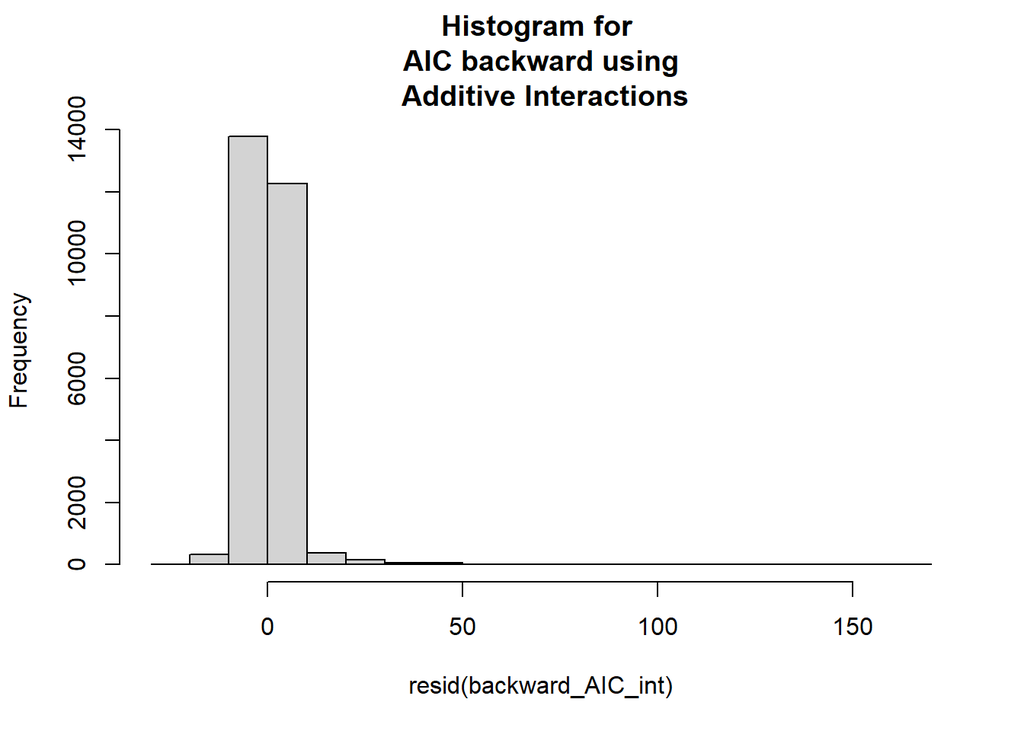

```r
hist(resid(backward_AIC_int), main = "Histogram for \nAIC backward using\n Additive Interactions")
```

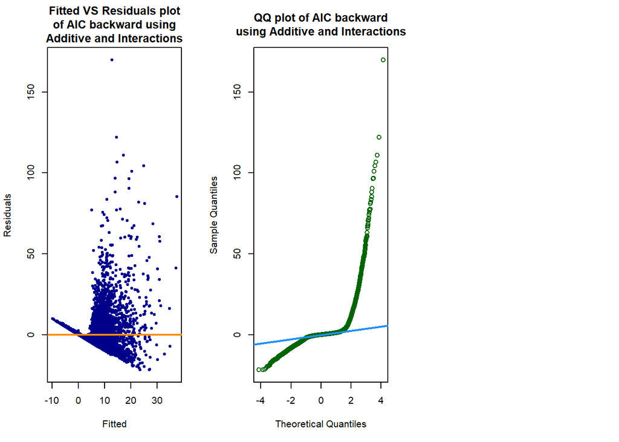

```r
get_plot('Fitted VS Residuals plot\nof AIC backward using\nAdditive and Interactions',
         'QQ plot of AIC backward\nusing Additive and Interactions',
         backward_AIC_int)
```

```r
backward_BIC_int$call
```

```
## lm(formula = Rainfall ~ Evaporation + Sunshine + Humidity9am +
##     Pressure9am + Temp9am + RainToday + Location + Evaporation:Location +
##     Humidity9am:Location + Pressure9am:Location + Temp9am:Location +
##     RainToday:Location, data = weather_trn)
```

[figure not shown]

```r
hist(resid(backward_AIC_int), main = "Histogram for \nBIC backward using\n Additive Interactions")
```

[figure not shown]

```r
get_plot('Fitted VS Residuals plot\nof BIC backward using\nAdditive and Interactions',
         'QQ plot of BIC backward\nusing Additive and Interactions',
         backward_AIC_int)
```

## Model Assumptions

### Additive only

##### Plots (only showing plots for best AIC and BIC)

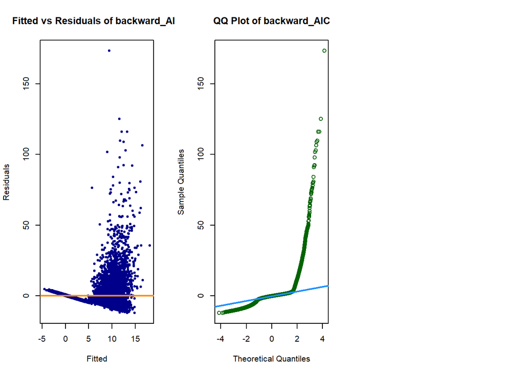

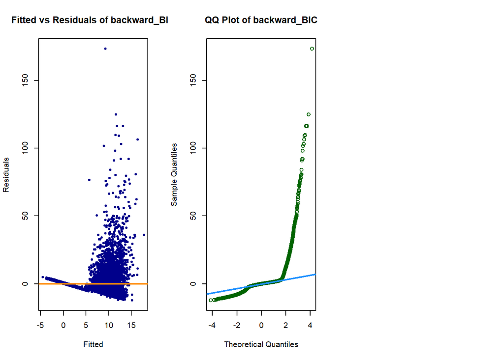

```r
get_plot(name_desc_fit = "Fitted vs Residuals of backward_AIC", name_desc_qq = "QQ Plot of backward_AIC", lm_mod = backward_AIC)
get_plot(name_desc_fit = "Fitted vs Residuals of backward_BIC", name_desc_qq = "QQ Plot of backward_BIC", lm_mod = backward_BIC)
```

##### Assumption tests

```r
shapiro.test(sample(resid(forward_AIC), size = 5000))
```

```
##
##  Shapiro-Wilk normality test
##
## data:  sample(resid(forward_AIC), size = 5000)
## W = 0.51402, p-value < 2.2e-16
```

```r
shapiro.test(sample(resid(forward_BIC), size = 5000))
```

```
##
##  Shapiro-Wilk normality test
##
## data:  sample(resid(forward_BIC), size = 5000)
## W = 0.41596, p-value < 2.2e-16
```

```r
shapiro.test(sample(resid(backward_AIC), size = 5000))
```

```
##
##  Shapiro-Wilk normality test
##
## data:  sample(resid(backward_AIC), size = 5000)
## W = 0.53825, p-value < 2.2e-16
```

```r
shapiro.test(sample(resid(backward_BIC), size = 5000))
```

```
##
##  Shapiro-Wilk normality test
##
## data:  sample(resid(backward_BIC), size = 5000)
## W = 0.50588, p-value < 2.2e-16
```

```r
shapiro.test(sample(resid(stepwise_AIC), size = 5000))
```

```
##
##  Shapiro-Wilk normality test
##
## data:  sample(resid(stepwise_AIC), size = 5000)
## W = 0.49294, p-value < 2.2e-16
```

```r
shapiro.test(sample(resid(stepwise_BIC), size = 5000))
```

```
##
##  Shapiro-Wilk normality test
##
## data:  sample(resid(stepwise_BIC), size = 5000)
## W = 0.43615, p-value < 2.2e-16
```

```r
library(lmtest)

bptest(forward_AIC)
```

```
##
##  studentized Breusch-Pagan test
##
## data:  forward_AIC
## BP = 1070.2, df = 19, p-value < 2.2e-16
```

```r
bptest(forward_BIC)
```

```
##
##  studentized Breusch-Pagan test
##
## data:  forward_BIC
## BP = 1058.1, df = 17, p-value < 2.2e-16
```

```r
bptest(backward_AIC)
```

```
##
##  studentized Breusch-Pagan test
##
## data:  backward_AIC
## BP = 1116.5, df = 30, p-value < 2.2e-16
```

```r
bptest(backward_BIC)
```

```
##
##  studentized Breusch-Pagan test
##
## data:  backward_BIC
## BP = 1091.5, df = 25, p-value < 2.2e-16
```

```r
bptest(stepwise_AIC)
```

```
##
##  studentized Breusch-Pagan test
##
## data:  stepwise_AIC
## BP = 1070.2, df = 19, p-value < 2.2e-16
```

```r
bptest(stepwise_BIC)
```

```
##
##  studentized Breusch-Pagan test
##
## data:  stepwise_BIC
## BP = 1058.1, df = 17, p-value < 2.2e-16
```

### Additive and interaction

##### Plots (only showing plots for best AIC and BIC)

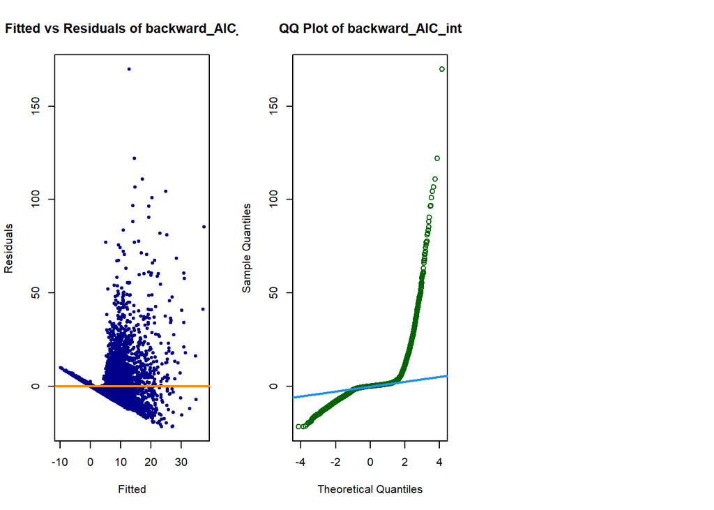

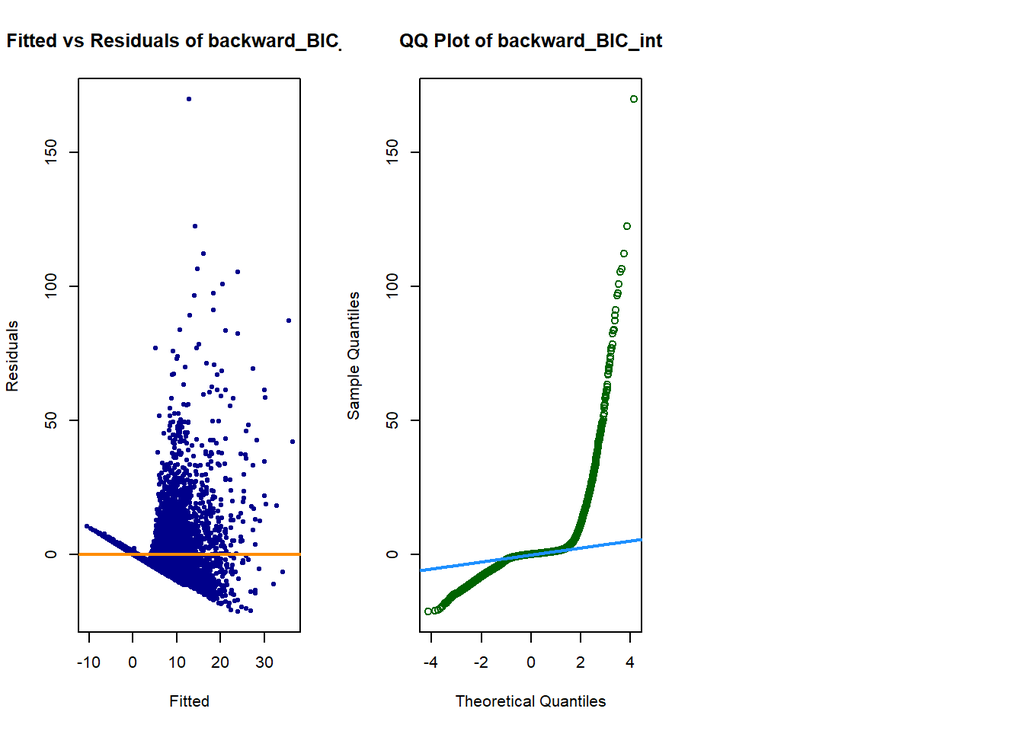

```r
get_plot(name_desc_fit = "Fitted vs Residuals of backward_AIC_int", name_desc_qq = "QQ Plot of backward_AIC_int", lm_mod = backward_AIC_int)
get_plot(name_desc_fit = "Fitted vs Residuals of backward_BIC_int", name_desc_qq = "QQ Plot of backward_BIC_int", lm_mod = backward_BIC_int)
```

##### Assumption tests

```r
shapiro.test(sample(resid(forward_AIC_int), size = 5000))
```

```
##
##  Shapiro-Wilk normality test
##
## data:  sample(resid(forward_AIC_int), size = 5000)
## W = 0.47156, p-value < 2.2e-16
```

```r
shapiro.test(sample(resid(forward_BIC_int), size = 5000))
```

```
##
##  Shapiro-Wilk normality test
##
## data:  sample(resid(forward_BIC_int), size = 5000)
## W = 0.53318, p-value < 2.2e-16
```

```r
shapiro.test(sample(resid(backward_AIC_int), size = 5000))
```

```
##
##  Shapiro-Wilk normality test
##
## data:  sample(resid(backward_AIC_int), size = 5000)
## W = 0.5701, p-value < 2.2e-16
```

```r
shapiro.test(sample(resid(backward_BIC_int), size = 5000))
```

```
##
##  Shapiro-Wilk normality test
##
## data:  sample(resid(backward_BIC_int), size = 5000)
## W = 0.52726, p-value < 2.2e-16
```

```r
shapiro.test(sample(resid(stepwise_AIC_int), size = 5000))
```

```
##
##  Shapiro-Wilk normality test
##
## data:  sample(resid(stepwise_AIC_int), size = 5000)
## W = 0.51082, p-value < 2.2e-16
```

```r
shapiro.test(sample(resid(stepwise_BIC_int), size = 5000))
```

```
##
##  Shapiro-Wilk normality test
##
## data:  sample(resid(stepwise_BIC_int), size = 5000)
## W = 0.52547, p-value < 2.2e-16
```

```r
library(lmtest)

bptest(forward_AIC_int)
```

```
##
##  studentized Breusch-Pagan test
##
## data:  forward_AIC_int
## BP = 1789, df = 116, p-value < 2.2e-16
```

```r
bptest(forward_BIC_int)
```

```
##
##  studentized Breusch-Pagan test
##
## data:  forward_BIC_int
## BP = 1770.1, df = 90, p-value < 2.2e-16
```

```r
bptest(backward_AIC_int)
```

```
##
##  studentized Breusch-Pagan test
##
## data:  backward_AIC_int
## BP = 1789, df = 116, p-value < 2.2e-16
```

```r
bptest(backward_BIC_int)
```

```
##
##  studentized Breusch-Pagan test
##
## data:  backward_BIC_int
## BP = 1723.8, df = 78, p-value < 2.2e-16
```

```r
bptest(stepwise_AIC_int)
```

```
##
##  studentized Breusch-Pagan test
##
## data:  stepwise_AIC_int
## BP = 1789, df = 116, p-value < 2.2e-16
```

```r
bptest(stepwise_BIC_int)
```

```
##
##  studentized Breusch-Pagan test
##
## data:  stepwise_BIC_int
## BP = 1723.8, df = 78, p-value < 2.2e-16
```

## Unusual observations

##### Calculating cook’s distance

```r
#cooks.distance(forward_AIC)
#cooks.distance(forward_BIC)

#cooks.distance(backward_AIC)
#cooks.distance(backward_BIC)

#cooks.distance(stepwise_AIC)
#cooks.distance(stepwise_BIC)

#cooks.distance(forward_AIC_int)
#cooks.distance(forward_BIC_int)

cooks_AIC = sort(cooks.distance(backward_AIC_int)[cooks.distance(backward_AIC_int) > 4 / length(backward_AIC_int$fitted.values)], decreasing = TRUE)[1:10]
cooks_AIC
```

```
##     106330     141755      86415      84840      87597      88224      86830
## 0.05202073 0.04737176 0.04353106 0.04107773 0.02648399 0.02208427 0.02055691
##      80821     141398      88027
## 0.02008646 0.02002756 0.01996375
```

```r
cooks_BIC = sort(cooks.distance(backward_BIC_int)[cooks.distance(backward_BIC) > 4 / length(backward_BIC_int$fitted.values)], decreasing = TRUE)[1:10]
cooks_BIC
```

```
##     106330      84840      86415     141755      87597      86815      86830
## 0.06456557 0.05763011 0.05053012 0.05044690 0.03372755 0.02721752 0.02708984
##      89697      88027     141398
## 0.02490097 0.02487259 0.02447220
```

```r
#cooks.distance(stepwise_AIC_int)
#cooks.distance(stepwise_BIC)
```

```r
#AIC_ind = as.array(names(cooks_AIC))
#BIC_ind = as.array(names(cooks_BIC))

#which.max(cooks.distance(backward_AIC_int)[cooks.distance(backward_AIC_int) > 4 / length(backward_AIC_int$fitted.values)])

weather_rmv_obs_AIC = weather_trn[rownames(weather_trn) != "88223", ] #weather_trn[-(AIC_ind), ]
weather_rmv_obs_BIC = weather_trn[rownames(weather_trn) != "88223", ]
```

##### Refitting models

```r
AIC_refit = lm(formula = Rainfall ~ (Date + Evaporation + Sunshine + Humidity9am + Pressure9am + Cloud9am + Temp9am + RainToday) * Location, data = weather_rmv_obs_AIC)
BIC_refit = lm(formula = Rainfall ~ Evaporation + Sunshine + Humidity9am + Pressure9am + Temp9am + RainToday + Location +
                                    Evaporation:Location + Humidity9am:Location + Pressure9am:Location + Temp9am:Location +
                                    RainToday:Location, data = weather_rmv_obs_BIC)
```

##### Calculating LOOCV RMSE on train data

```r
AIC_refit_RMSE_loocv = calc_loocv_rmse(AIC_refit)
BIC_refit_RMSE_loocv = calc_loocv_rmse(BIC_refit)
AIC_refit_RMSE_loocv
```

```
## [1] 5.63908
```

```r
BIC_refit_RMSE_loocv
```

```
## [1] 5.646729
```

##### Calculating RMSE on test data

```r
AIC_refit_RMSE = sqrt(mean((weather_tst$Rainfall - predict(AIC_refit, newdata = weather_tst)) ^ 2))
BIC_refit_RMSE = sqrt(mean((weather_tst$Rainfall - predict(BIC_refit, newdata = weather_tst)) ^ 2))
AIC_refit_RMSE
```

```
## [1] 5.818235
```

```r
BIC_refit_RMSE
```

```
## [1] 5.82495
```

##### Adjusted $R^2$

```r
AIC_refit_adj_r_sq = test_adj_r_sqr(pred_val = predict(AIC_refit, newdata = weather_tst), actual_val = weather_tst$Rainfall, lm_mod = AIC_refit)
BIC_refit_adj_r_sq = test_adj_r_sqr(pred_val = predict(BIC_refit, newdata = weather_tst), actual_val = weather_tst$Rainfall, lm_mod = BIC_refit)
```

##### Results

```r
df_table = data.frame(RSME_loocv = c(AIC_refit_RMSE_loocv, BIC_refit_RMSE_loocv),
                      RMSE_test = c(AIC_refit_RMSE, BIC_refit_RMSE),
                      adjusted_r_squared = c(AIC_refit_adj_r_sq, BIC_refit_adj_r_sq),
                      model_call = c(toString(AIC_refit$call), toString(BIC_refit$call)),
                      row.names = c("AIC_refit", "BIC_refit"))
df_table
```

```
##           RSME_loocv RMSE_test adjusted_r_squared
## AIC_refit   5.639080  5.818235          0.1325592
## BIC_refit   5.646729  5.824950          0.1335255
##                                                                                                                                                                                                                                     model_call
## AIC_refit                                                                                          lm, Rainfall ~ (Date + Evaporation + Sunshine + Humidity9am + Pressure9am + Cloud9am + Temp9am + RainToday) * Location, weather_rmv_obs_AIC
## BIC_refit lm, Rainfall ~ Evaporation + Sunshine + Humidity9am + Pressure9am + Temp9am + RainToday + Location + Evaporation:Location + Humidity9am:Location + Pressure9am:Location + Temp9am:Location + RainToday:Location, weather_rmv_obs_BIC
```

```r
knitr::kable(df_table)
```

|  | RSME_loocv | RMSE_test | adjusted_r_squared | model_call |
| --- | --- | --- | --- | --- |
| AIC_refit | 5.639080 | 5.818235 | 0.1325592 | lm, Rainfall ~ (Date + Evaporation + Sunshine + Humidity9am + Pressure9am + Cloud9am + Temp9am + RainToday) * Location, weather_rmv_obs_AIC |
| BIC_refit | 5.646729 | 5.824950 | 0.1335255 | lm, Rainfall ~ Evaporation + Sunshine + Humidity9am + Pressure9am + Temp9am + RainToday + Location + Evaporation:Location + Humidity9am:Location + Pressure9am:Location + Temp9am:Location + RainToday:L… |